# Data Exploration in R

OpenSDP

August 15, 2017

# Data Exploration in R

The purpose of this tutorial is to 1) provide a R refresher for education data analysts who are not yet comfortable using R, and 2) demonstrate some useful data exploration commands. You don’t need to know any R to do this tutorial.

This tutorial is fairly basic, so to put the material into the context of your own work, here is some advice about what it takes to become proficient in R, the typical steps involved in using R for an analysis project, and staying organized. Learning R is hard work, but it can be very rewarding! As you learn R, you’ll build your skills and understanding in a number of ways. If you don’t have programming experience, you’ll be getting used to writing programs to tell R what to do with your data. You’ll learn the syntax and options for various commands, and memorize the most important ones. Since you’ll be summarizing and manipulating very large datasets with hundreds of thousands or millions of lines, you’ll get used to keeping a picture of the data and its structure in your head as you work, figuring out how different commands will affect the data, and checking whether what you think you did to the data is what actually happened.

Getting first comfortable and then expert in R will take time. You can learn some basic commands very quickly, but to learn how to unleash the full power of R can take three to six months of steady effort. This means that to get enough practice to become proficient you will probably need to use R in your daily work, and most of your learning will happen on your own. As you grow your R skills, you should seek out a variety of resources to help you figure out how to tackle different problems: the excellent R help system, colleagues and fellow R programmers, the SDP R Slack channel, and online websites and training resources.

For a typical analysis cycle, you will acquire data, load it into R, and spend some time exploring it to get to know the data, assessing the data quality and uncovering problems with the data. Then, you’ll use data manipulation commands to “clean” and prepare the data. You’ll apply decision rules to make it internally consistent, label and reformat the variables, combine and reshape data from different sources, and define the new variables you need. This data wrangling phase typically takes most of the time and effort in a statistical programming project.

Once the data is prepared, you can use data exploration commands again to do descriptive analysis. Depending on your comfort level with statistics and econometrics, you can call on R’s extensive modeling tools to dig deeper into statistical analysis and forecasting. Finally, you will probably spend significant time preparing and polishing charts to use in sharing the results of your analysis. You can use R’s extensive library of data visualization commands to prepare charts, or copy analysis results from R and make the charts in a different program you are already familiar with such as Excel.

When you start an analysis project, you should spend some time thinking about how you will organize your work. For training purposes, you can put programs and data files in a single folder on your computer desktop, but eventually you will need to separate your files. One suggestion is to use one folder per project, with separate subfolders for R programs, data, and output such as tables and charts.

You should never save over your original, or “raw” data. Instead, you can write commands in an “R script” (an R program) to clean your data, define new variables, save the updated dataset to a new file, and then run analyses. If you need to update the data later or make other changes you can edit the do file, re-run it, re-save the cleaned dataset, and regenerate the analyses. In this way your work will be reproducible for someone else, including you in the future, can review your do file and data to recreate how an analysis was done. Now, on to the tutorial! It has two parts. In Part 1, you will see how to use data exploration commands to inspect a student-level dataset. In Part 2, you’ll get practice using data exploration commands to answer simple research questions.

# Pre-Flight

Before beginning this tutorial, make sure you have RStudio installed on your computer. RStudio is the absolute best way for beginners and seasoned R veterans alike to interface with R on any platform. With RStudio you can interactively explore text, code, and data like in this tutorial, using formats such as R Markdown and R Notebooks.

Then, check out the Quickstart Guide and the Strategic Data Project R Glossary.

# Part One: Getting To Know the Data

When you double-clicked on this file to open it, RStudio should have opened with four panes–the editor pane which is showing this tutorial, the main R pane, the files/viewer pane, and the environment pane.

For our purposes, the two most important sections are the command window and the results window above it. For this part of the tutorial, you will enter R commands interactively. You can run commands directly from this file by clicking the green arrow on the top right above the code “chunks”, or by highlighting the command and clicking Run or Ctrl + Enter.

When the tutorial asks questions about the data, find the answers by looking at the output in the R results window, and then consult the “Answer Key” to see if you are right.

None of the commands in this part of the tutorial make changes to the data, so if you have to leave the tutorial and come back to it, you don’t have do redo the earlier part. Just reload the data by clicking on the command below, and then go to the section where you left off.

## First, load the data.

```r
library(dplyr) # loads a library of useful functions for data manipulation
# If dplyr is not installed use
# install.packages("dplyr")
# Use read.csv to import CSV style data
stu_data <- read.csv("data/Delawnymous_SSY_20170813.csv",
                     stringsAsFactors = FALSE)
```

This data file contains information about fictitious students in the state of Delawnymous. None of the students in the data actually exist, but the relationships in the data are based on those in a real student data file. This data has already been cleaned – that is, the data is not the same as the raw source data from the Delawnymous longitudinal data system. Inconsistencies and obvious data errors have been fixed, and the variables and values have been renamed and labeled.

If you haven’t used R much before, it will probably be helpful for you to look at the actual data first, to see how it is stored in R. Type `View(stu_data)` in the command window, and then scroll left and right and up and down through the data to see the information stored as variables (columns) and records or observations (rows). Close the browser window when you are done.

This file is a panel dataset, that means there is one row per student per school year. Thus the file has two key variables: student id, or `sid`, and `school_year`.

The first step in exploring the data is confirming that the data does in fact have exactly one record per student per year. We use the `n_distinct` function from the `dplyr` package in R to quickly do this. (Note: the `dplyr::n_distinct()` part is unnecessary, but is included here to show you that the function exists in a package, or extension to R. You can simply type `n_distinct()` after loading the package and R will know where to find the function.)

```r
dplyr::n_distinct(stu_data$sid)
```

```
[1] 200470
```

```r
dplyr::n_distinct(stu_data$sid, stu_data$school_year)
```

```
[1] 759520
```

## Next, let’s look at a list of the variables in the dataset.

```r
str(stu_data)
```

```
'data.frame':   759520 obs. of  23 variables:
 $ sid              : int  75357 77859 252963 126847 91450 71905 238840 121920 222806 125131 ...
 $ school_year      : int  2013 2012 2013 2016 2012 2014 2013 2011 2015 2014 ...
 $ school_code      : int  214 206 376 401 185 198 233 162 165 173 ...
 $ s_male           : int  1 0 0 1 1 0 0 1 1 1 ...
 $ s_birth_year     : int  1999 2008 1997 2002 2003 2000 2006 1997 2007 2005 ...
 $ s_race           : chr  "Black" "Asian" "White" "Black" ...
 $ s_frpl           : chr  "Free Lunch" NA "Free Lunch" "Does Not Qualify" ...
 $ s_ell            : int  0 NA 0 0 0 0 1 0 0 0 ...
 $ s_iep            : int  0 NA 1 1 0 0 0 0 1 0 ...
 $ s_grade_level    : chr  "7" "" "7" "8" ...
 $ s_days_absent    : int  7 NA 1 5 NA 4 8 NA 10 6 ...
 $ s_days_suspended : int  9 NA 0 0 0 0 0 0 0 0 ...
 $ std_scaled_m     : num  -1.175 NA -0.479 -0.756 1.308 ...
 $ std_scaled_e     : num  -0.78 NA 0.151 -1.155 0.287 ...
 $ sat_math_score   : int  NA NA NA NA NA NA NA NA NA NA ...
 $ sat_verbal_score : int  NA NA NA NA NA NA NA NA NA NA ...
 $ sat_writing_score: int  NA NA NA NA NA NA NA NA NA NA ...
 $ hs_diploma       : int  0 0 0 0 0 0 0 1 0 0 ...
 $ hs_diploma_year  : int  NA NA NA NA NA NA NA 2016 NA NA ...
 $ sch_charter      : int  0 0 0 0 0 0 0 0 0 0 ...
 $ sch_alternative  : int  0 0 0 1 0 0 0 0 0 0 ...
 $ sch_vocational   : int  0 0 0 0 0 0 0 0 0 0 ...
 $ record_type      : chr  "Fake data" "Fake data" "Fake data" "Fake data" ...
```

**Question 1: According to the output of the `str()` command, how many records (aka observations, or rows) are there in the dataset?**

[See answer key for results.]

In addition to student ID and school year, the dataset contains student demographic data, school information, grade level, attendance data, test scores, and high school graduation information.

The `n_distinct()` command confirms the structure of the data, and the `View()` and `str()` commands give an overview of the dataset. Next, it’s time to start looking at individual variables. As you look at each variable in a new dataset for the first time, these are some of the questions to consider:

**What type of variable is it?**

- Is it text or numeric?
- Is it a continuous variable (able to take many numeric values), or is it a categorical variable (limited to a smaller number of possible values representing specific categories)?
- If it is a categorical variable, is it stored as a text string, or is it numeric? Does it have labels that explain the categories?
- Is it a date or time variable? Or, is it a long text description that can take any number of values?
- It is a binary variable (often referred to as a “dummy,” indicator, or logical variable) which takes only two values, such as 1 or 0, typically interpreted as true/false or yes/no?
- What is the distribution of the variable?
- If it is a categorical variable, what share of observations fall in each category?
- If it is numeric, what are the maximum, minimum, average, standard deviation, median, and 25th and 75th percentile values?
- Can you identify any problems with the variable?
- Are there any missing values?
- Does it look like there are outliers (a few values that are unusually high or low)?
- Are there any impossible values?
- Are there variables which are formatted incorrectlyâ-for example, dates or numbers stored as strings?

One of the most useful commands when you are in the “getting to know the data” phase is the `summary()` command. This command answers many of the questions above all at once. You can use it to find out information about just one variable. In R, whenever we reference a dataset, we need to tell R which dataset we want - in this case `stu_data`, and we use the `$` to tell R to look for the `school_year` variable within the `stu_data` dataset. In RStudio, the editor will autocomplete for you as you are typing, helping you search the columns within a dataset.

```r
summary(stu_data$school_year)
```

```
   Min. 1st Qu.  Median    Mean 3rd Qu.    Max.
   2011    2012    2014    2014    2015    2016
```

Or you can look at several variables, or all the variables in the dataset. Here we specify a vector of variable names `c("sat_math_score", "sat_verbal_score")` (notice the quotation marks), and we tell R we want all rows (nothing before the comma), but only the columns in the set of names that come after the comma.

```r
summary(stu_data[, c("sat_math_score", "sat_verbal_score", "sat_writing_score")])
```

```
 sat_math_score   sat_verbal_score sat_writing_score
 Min.   :200.0    Min.   :200.0    Min.   :200.0
 1st Qu.:390.0    1st Qu.:380.0    1st Qu.:370.0
 Median :460.0    Median :450.0    Median :430.0
 Mean   :462.3    Mean   :453.8    Mean   :442.8
 3rd Qu.:530.0    3rd Qu.:530.0    3rd Qu.:510.0
 Max.   :800.0    Max.   :800.0    Max.   :800.0
 NA's   :654558   NA's   :654558   NA's   :654564
```

**Question 2: What are the average and 25th percentile fo SAT math scores for the records in the data which have SAT scores?**

Go ahead and look through the entire list of variables using the `summary()` command. After all the results have been displayed, you can scroll up and down through the results window to review the output. Review the output, keeping the questions above in mind.

```r
summary(stu_data)
```

```
      sid          school_year    school_code        s_male
 Min.   : 60001   Min.   :2011   Min.   :151.0   Min.   :0.0000
 1st Qu.:111068   1st Qu.:2012   1st Qu.:209.0   1st Qu.:0.0000
 Median :162350   Median :2014   Median :274.0   Median :1.0000
 Mean   :162441   Mean   :2014   Mean   :274.8   Mean   :0.5166
 3rd Qu.:213772   3rd Qu.:2015   3rd Qu.:336.0   3rd Qu.:1.0000
 Max.   :264947   Max.   :2016   Max.   :408.0   Max.   :1.0000

  s_birth_year     s_race             s_frpl              s_ell
 Min.   :1978   Length:759520      Length:759520      Min.   :0.000
 1st Qu.:1998   Class :character   Class :character   1st Qu.:0.000
 Median :2001   Mode  :character   Mode  :character   Median :0.000
 Mean   :2001                                         Mean   :0.054
 3rd Qu.:2004                                         3rd Qu.:0.000
 Max.   :2015                                         Max.   :1.000
                                                      NA's   :17420
     s_iep       s_grade_level      s_days_absent    s_days_suspended
 Min.   :0.000   Length:759520      Min.   :  0.00   Min.   :  0.000
 1st Qu.:0.000   Class :character   1st Qu.:  3.00   1st Qu.:  0.000
 Median :0.000   Mode  :character   Median :  7.00   Median :  0.000
 Mean   :0.152                      Mean   :  9.63   Mean   :  0.718
 3rd Qu.:0.000                      3rd Qu.: 12.00   3rd Qu.:  0.000
 Max.   :1.000                      Max.   :307.00   Max.   :193.000
 NA's   :17420                      NA's   :261829   NA's   :17420
  std_scaled_m     std_scaled_e    sat_math_score   sat_verbal_score
 Min.   :-3.94    Min.   :-5.72    Min.   :200.0    Min.   :200.0
 1st Qu.:-0.70    1st Qu.:-0.63    1st Qu.:390.0    1st Qu.:380.0
 Median :-0.07    Median : 0.04    Median :460.0    Median :450.0
 Mean   :-0.01    Mean   :-0.01    Mean   :462.3    Mean   :453.8
 3rd Qu.: 0.62    3rd Qu.: 0.65    3rd Qu.:530.0    3rd Qu.:530.0
 Max.   : 5.73    Max.   : 4.80    Max.   :800.0    Max.   :800.0
 NA's   :267013   NA's   :268855   NA's   :654558   NA's   :654558
 sat_writing_score   hs_diploma     hs_diploma_year   sch_charter
 Min.   :200.0     Min.   :0.0000   Min.   :2008     Min.   :0.00000
 1st Qu.:370.0     1st Qu.:0.0000   1st Qu.:2013     1st Qu.:0.00000
 Median :430.0     Median :0.0000   Median :2015     Median :0.00000
 Mean   :442.8     Mean   :0.2097   Mean   :2014     Mean   :0.06613
 3rd Qu.:510.0     3rd Qu.:0.0000   3rd Qu.:2016     3rd Qu.:0.00000
 Max.   :800.0     Max.   :1.0000   Max.   :2016     Max.   :1.00000
 NA's   :654564                     NA's   :600258
 sch_alternative  sch_vocational    record_type
 Min.   :0.0000   Min.   :0.00000   Length:759520
 1st Qu.:0.0000   1st Qu.:0.00000   Class :character
 Median :0.0000   Median :0.00000   Mode  :character
 Mean   :0.0225   Mean   :0.05033
 3rd Qu.:0.0000   3rd Qu.:0.00000
 Max.   :1.0000   Max.   :1.00000
```

By default, `summary()` is not very informative about data elements that are character or factor values – non-numeric data. The `table()` command gives you two pieces of information: the different values of a categorical variable, and the number of records which have each value.

```r
table(stu_data$s_male)
```

```
     0      1
367162 392358
```

```r
table(stu_data$s_birth_year)
```

```
 1978  1979  1988  1989  1990  1991  1992  1993  1994  1995  1996  1997  1998
    2     4     3    26   124   475  2991 12971 24091 35039 44032 53429 58672
 1999  2000  2001  2002  2003  2004  2005  2006  2007  2008  2009  2010  2011
55297 56787 55677 56407 56264 57491 52764 45120 37525 27190 17329  7937  1289
 2012  2013  2014  2015
  514    30    15    25
```

```r
table(stu_data$s_race)
```

```
          Asian           Black        Hispanic        Multiple Native American
          24634          245252           88928            8785            3477
          Other           White
            286          388158
```

```r
table(stu_data$s_frpl)
```

```
Does Not Qualify       Free Lunch    Reduced Lunch
          412988           281840            47272
```

By default, R excludes missing values when it tabulates a variable. You can tell this because the total number of records shown is lower than the total number of records in the dataset. You can verify the total number of records in the dataset with the `nrow` command:

```r
nrow(stu_data)
```

```
[1] 759520
```

To make R show the records with missing values, use the `table()` command with the `useNA = "always"` option. R uses the period `<NA>` symbol to indicate missing values.

```r
table(stu_data$s_frpl, useNA = "always")
```

```
Does Not Qualify       Free Lunch    Reduced Lunch             <NA>
          412988           281840            47272            17420
```

It’s good practice to always use the missing option when you’re exploring data unless you specifically want to know the percentages of records in different categories excluding the missing records. Go ahead and look at the distributions of the rest of the categorical variables:

(Note: You can optionally label the output of the table, so the output is easier to read when you have multiple tables in the console, just declare a name and set it equal to the data element you want to tabulate. Your name cannot have a space in it though.)

```r
table(ell = stu_data$s_ell, useNA = "always")
```

```
ell
     0      1   <NA>
702336  39764  17420
```

```r
table(iep = stu_data$s_iep, useNA = "always")
```

```
iep
     0      1   <NA>
629308 112792  17420
```

```r
table(grade = stu_data$s_grade_level, useNA = "always")
```

```
grade
          1    10    11    12     2     3     4     5     6     7     8     9
17420 59841 58446 50275 46371 57187 57377 56697 56426 57226 57980 58571 67296
    K Pre-K  <NA>
53820  4587     0
```

```r
table(grad = stu_data$hs_diploma, useNA = "always")
```

```
grad
     0      1   <NA>
600258 159262      0
```

```r
table(grad_year = stu_data$hs_diploma_year, useNA = "always")
```

```
grad_year
  2008   2009   2010   2011   2012   2013   2014   2015   2016   <NA>
    24     53    123   7258  14501  22551  30074  39524  45154 600258
```

```r
table(hi_grade = stu_data$sch_high_grade, useNA = "always")
```

```
hi_grade
<NA>
   0
```

```r
table(lo_grade = stu_data$sch_low_grade, useNA = "always")
```

```
lo_grade
<NA>
   0
```

```r
table(stu_data$sch_high, useNA = "always")
```

```
<NA>
   0
```

```r
table(stu_data$sch_charter, useNA = "always")
```

```
     0      1   <NA>
709294  50226      0
```

```r
table(stu_data$sch_alternative, useNA = "always")
```

```
     0      1   <NA>
742434  17086      0
```

```r
table(stu_data$sch_vocational, useNA = "always")
```

```
     0      1   <NA>
721296  38224      0
```

**Question 3: How many values are there for s_frpl?**

**Question 4: What is the relationship between missing values for hs_diploma_year and the hs_diploma variable?**

**Question 5: Can you identify some binary “dummy” or indicator variables?**

When you get a new dataset, it’s a good idea to run the codebook command to get an overview of the data. After that, you should inspect some of the most important variables one or a few at a time. This dataset has a relatively small number of variables, so we’ll be able to look at all of them. For initial data inspection, the `table()` command is the most useful command for categorical variables. The `summary()` and `hist()` commands are most useful for continuous variables.

**Question 6: What share of records are missing grade level?**

**Question 7: Are there any other variables which have the same missingness pattern?**

**Question 8: What share of students have an Individualized Education Plan?**

`table()` can also be useful for comparing the joint distributions of two variables. The resulting tables are often referred to as crosstabs. Since you’ll be doing this a lot in the hands-on exercise for the fall workshop, it’s worth taking the time to make sure that you are comfortable with making and interpreting crosstabs.

When you ask R to make a `table()` of two variables, R generates a table with the first variable’s categories in the rows of the table, and the second variable’s categories in the columns. The cells in the table give the total number of records which fall into each combined category. Again, you can label each element of the table with an optional label if you want as well.

```r
table(race = stu_data$s_race, charter = stu_data$sch_charter, useNA="always")
```

```
                 charter
race                   0      1   <NA>
  Asian            22020   2614      0
  Black           224666  20586      0
  Hispanic         85592   3336      0
  Multiple          8294    491      0
  Native American   3287    190      0
  Other              272     14      0
  White           365163  22995      0
  <NA>                 0      0      0
```

```r
table(stu_data$s_race, useNA="always")
```

```
          Asian           Black        Hispanic        Multiple Native American
          24634          245252           88928            8785            3477
          Other           White            <NA>
            286          388158               0
```

```r
table(stu_data$sch_charter, useNA="always")
```

```
     0      1   <NA>
709294  50226      0
```

**Question 9: How many records in the dataset are for Black students attending charter schools?**

For two-way tabulations, R does not automatically provide percentages. This makes it harder to see if the racial and ethnic distribution for charter school students is different from the rest of the school population. In R `prop.table()` converts a `table()` to a proportion table. You specify the `margin` to tell R whether you want row, column, or cell proportions Set `margin = 1` for row, `margin = 2` for column proportions

Note that `prop.table` is a function that must be combined with `table`. This pattern of nesting functions is common in R. Later we’ll see an intuitive way to chain functions together so that the commands are easier to read.

```r
prop.table(
  table(stu_data$s_race, stu_data$sch_charter, useNA="always"),
           margin = 2)
```

```
                             0            1 <NA>
  Asian           0.0310449546 0.0520447577
  Black           0.3167459474 0.4098673994
  Hispanic        0.1206721049 0.0664197826
  Multiple        0.0116933176 0.0097758133
  Native American 0.0046341855 0.0037829013
  Other           0.0003834799 0.0002787401
  White           0.5148260101 0.4578306057
  <NA>            0.0000000000 0.0000000000
```

Here we see for the school years in the dataset, of students not attending charters, 32 percent are Black; and of students attending charters, 41 percent are Black. Notice that R reports proportions, not percentages, by default - multiply by 100 to get the percentages.

**Question 10: Are Hispanic student relatively more or less likely to attend charter schools?**

Now, look at the same data using row proportions.

```r
prop.table(
  table(stu_data$s_race, stu_data$sch_charter, useNA="always"),
           margin = 1)
```

```
                           0          1       <NA>
  Asian           0.89388650 0.10611350 0.00000000
  Black           0.91606185 0.08393815 0.00000000
  Hispanic        0.96248651 0.03751349 0.00000000
  Multiple        0.94410928 0.05589072 0.00000000
  Native American 0.94535519 0.05464481 0.00000000
  Other           0.95104895 0.04895105 0.00000000
  White           0.94075866 0.05924134 0.00000000
  <NA>
```

**Question 11: How would you interpret the percentages for Black students compared to all students?**

Now, look at the same data using cell proportions. This time, let’s add the `round()` command to make the output more readable. By specifying `digits = 4` we are telling R where we want to round at.

```r
round(
  prop.table(
    table(stu_data$s_race, stu_data$sch_charter,
                       useNA="always")
    ),
  digits = 4)
```

```
                       0      1   <NA>
  Asian           0.0290 0.0034 0.0000
  Black           0.2958 0.0271 0.0000
  Hispanic        0.1127 0.0044 0.0000
  Multiple        0.0109 0.0006 0.0000
  Native American 0.0043 0.0003 0.0000
  Other           0.0004 0.0000 0.0000
  White           0.4808 0.0303 0.0000
  <NA>            0.0000 0.0000 0.0000
```

**Question 12: Explain the figure 0.0271 in the second row.**

One problem with these tabulations is that they pool data from six school years. This improves sample size but it means that the data is less current.

As with anything in R, there are multiple ways to handle this. Let’s use this as a good time to introduce the `%>%` command. This command allows you to “chain” or “pipe” commands together, without nesting functions like above. This helps make your intuitive to read. See if you can follow the chain below:

```r
stu_data %>%
  filter(school_year == 2016) %>%
  select(s_race, sch_charter) %>%
  table(useNA = "always") %>% prop.table(margin = 2)
```

```
                 sch_charter
s_race                       0            1 <NA>
  Asian           0.0333084784 0.0539011634
  Black           0.3115880628 0.4042053581
  Hispanic        0.1331746005 0.0872024763
  Multiple        0.0170990866 0.0131284022
  Native American 0.0050331305 0.0038424592
  Other           0.0005931299 0.0006404099
  White           0.4992035113 0.4370797310
  <NA>            0.0000000000 0.0000000000
```

We start with the `stu_data` dataset, we `filter()` to include only the rows for the year 2016, we `select()` only the columns `s_race` and `sch_charter`, we put these in a `table()`, and include missing values, and then we compute a `prop.table()` using column proportions.

Note that R uses a double equals sign to indicate equality, a single equals sign is used to set variables or function arguments.

Next, let’s look at high school graduates. First, verify that diploma year is missing for non-graduates.

```r
table(stu_data$hs_diploma_year, stu_data$hs_diploma, useNA = "always")
```

```
            0      1   <NA>
  2008      0     24      0
  2009      0     53      0
  2010      0    123      0
  2011      0   7258      0
  2012      0  14501      0
  2013      0  22551      0
  2014      0  30074      0
  2015      0  39524      0
  2016      0  45154      0
  <NA> 600258      0      0
```

You can see that all the non-graduates had a high-school graduation year of `<NA>`, or missing. Crosstabbing two related variables to see if they are consistent with one another is a common data inspection chore. Next, let’s use row and column filters to look at graduates across school years.

To get a better idea of how the data is structured, first sort it by student ID and school year, and then browse just the records for students who graduated. In R, you often want to manipulate your data object, and use the `<-` operator to overwrite it – here we overwrite `stu_data` with a sorted version of the same data.

```r
stu_data <- stu_data %>% arrange(sid, school_year)
View(stu_data[stu_data$hs_diploma == 1, ])
```

You can browse just the variables of interest to make the data easier to inspect. Note here that we use the `[]` after `stu_data` to tell R what “index” or specific elements of the `stu_data` we want to include. In this case, the first element of the bracket tells R we want all rows where `stu_data$hs_diploma == 1`, then after the comma, we tell R which columns, or variables, we want to include.

```r
View(
  stu_data[stu_data$hs_diploma == 1,
           c("sid", "school_year", "hs_diploma", "hs_diploma_year")]
  )
```

It looks like the high school diploma year is the last school year for each graduate in the dataset. Armed with this understanding, let’s count the number of graduates each year. A quick way to do this is to select only those rows where the `hs_diploma_year` is identical to the `school_year` and then tabulate the `school_year` to count how many graduates are in each year.

Because we are only working with a single variable, when we use the `[]` we do not include a filter for rows and columns, but only one conditional statement. This is because `stu_data$school_year` only has one dimension and we can only filter it on that dimension.

```r
table(
  stu_data$school_year[stu_data$hs_diploma_year == stu_data$school_year],
      useNA = "always")
```

```
  2011   2012   2013   2014   2015   2016   <NA>
  6895   7136   7597   7746   8378   8186 600258
```

In general, when you are first exploring an education dataset that is in panel format, with an id variable (for example, students, schools, or teachers) and a time variable (usually school years), it’s a good idea to inspect the data by crosstabbing important variables by time and place: school year and a geographic variable like school or district. This can help reveal patterns in the data and possibly surface problems with data coverage and consistency.

Start by looking at school enrollment across years. Note that you should put variables with large numbers of categories first in a `table()` command. For tables where you will expect a lot of output, it can be helpful to save them as another object in your workspace so you can work with them directly:

```r
table(stu_data$school_code, stu_data$school_year, useNA="always")
```

```
       2011 2012 2013 2014 2015 2016 <NA>
  151   338  375  357  367  378  325    0
  152   296  371  255  231  242  216    0
  153   532  591  608  618  554  559    0
  154   867  884  728  813  887  885    0
  155  1452 1367 1133 1442 1531 1544    0
  156   691  738  814  985  996  852    0
  157   319  435  331  314  238  220    0
  158   461  506  533  471  476  453    0
  159  1145  959  710  619  621  530    0
  160   832  810  702  703  712  764    0
  161   860  892  893  791  681  625    0
  162   758  774  673  792  787  784    0
  163   702  725  703  734  663  708    0
  164   423  431  558  451  482  419    0
```

[output cut: 244 more lines]

**Question 13: What happened to schools 166 and 219?**

Look at school year and grade level.

```r
table(stu_data$s_grade_level, stu_data$school_year, useNA = "always")
```

```
         2011  2012  2013  2014  2015  2016  <NA>
         3716  3815  3600  4800   879   610     0
  1      9529  9862  9962 10169 10218 10101     0
  10     9594  9598  9760 10285  9866  9343     0
  11     7898  8144  8369  8489  8907  8468     0
  12     6851  7422  7715  7735  8159  8489     0
  2      9144  9364  9497  9671  9909  9602     0
  3      9090  9330  9504  9537  9821 10095     0
  4      9094  9206  9329  9631  9597  9840     0
  5      9020  9190  9316  9371  9792  9737     0
  6      9258  9240  9383  9623  9735  9987     0
  7      9856  9488  9474  9552  9756  9854     0
  8      9977 10264  9777  9373  9488  9692     0
  9     11167 10970 11549 11384 11054 11172     0
  K      8590  8598  8964  9314  9196  9158     0
  Pre-K   286   577   679   505  1301  1239     0
  <NA>      0     0     0     0     0     0     0
```

This raises some questions: Did the number of students in Pre-K increase over time, or did recordkeeping improve? Is the large number of ninth graders due to a retention policy?

Look at days absent and suspended. Since these variables are numeric with many unique values, we can count the rows that pass some threshold. Note that you can just include the logical test alongside the variable in the `table()` command itself, and it will return `TRUE` or `FALSE` for observations that meet that test (in this case students with any absences).

```r
table(stu_data$s_days_absent > 0, stu_data$school_year, useNA = "always")
```

```
          2011   2012   2013   2014   2015   2016   <NA>
  FALSE      0      0   8307   6574   7933  11326      0
  TRUE       0      0 113858 116888 117921 114884      0
  <NA>  123070 125068   4713   5977   1824   1177      0
```

```r
table(stu_data$s_days_suspended > 0, stu_data$school_year, useNA = "always")
```

```
          2011   2012   2013   2014   2015   2016   <NA>
  FALSE 104544 105924 101544 103551 106799 107662      0
  TRUE   14810  15329  21734  21088  20000  19115      0
  <NA>    3716   3815   3600   4800    879    610      0
```

Do you see any issues?

Check other variables quickly, and see if everything is as you expect.

```r
prop.table(table(stu_data$school_year, stu_data$s_male, useNA = "always"),
           margin = 1)
```

```
               0         1      <NA>
  2011 0.4811977 0.5188023 0.0000000
  2012 0.4824575 0.5175425 0.0000000
  2013 0.4840004 0.5159996 0.0000000
  2014 0.4836564 0.5163436 0.0000000
  2015 0.4841946 0.5158054 0.0000000
  2016 0.4848768 0.5151232 0.0000000
  <NA>
```

```r
prop.table(table(stu_data$s_birth_year, stu_data$school_year, useNA = "always"),
           margin = 1)
```

```
               2011         2012         2013         2014         2015
  1978 0.5000000000 0.5000000000 0.0000000000 0.0000000000 0.0000000000
  1979 0.5000000000 0.2500000000 0.2500000000 0.0000000000 0.0000000000
  1988 0.6666666667 0.3333333333 0.0000000000 0.0000000000 0.0000000000
  1989 0.7692307692 0.1923076923 0.0384615385 0.0000000000 0.0000000000
  1990 0.6935483871 0.1854838710 0.0806451613 0.0161290323 0.0161290323
  1991 0.6800000000 0.2168421053 0.0610526316 0.0252631579 0.0084210526
  1992 0.7800066867 0.1447676362 0.0407890338 0.0140421264 0.0120361083
  1993 0.6785136073 0.2394572508 0.0463341300 0.0169609128 0.0117955439
  1994 0.4166701258 0.3836287410 0.1499315097 0.0319621435 0.0122452368
  1995 0.2974114558 0.2857102086 0.2698707155 0.1158708867 0.0235737321
  1996 0.2238826308 0.2261309956 0.2230423328 0.2143668241 0.0952943314
  1997 0.1807071066 0.1846749892 0.1890172004 0.1869396770 0.1778809261
  1998 0.1662803382 0.1669961822 0.1705754022 0.1725013635 0.1648997818
  1999 0.1623777058 0.1645116372 0.1675316925 0.1725229217 0.1702804854
```

[output cut: 50 more lines]

```r
prop.table(table(stu_data$school_year, stu_data$s_race, useNA = "always"),
           margin = 1)
```

```
              Asian        Black     Hispanic     Multiple Native American
  2011 0.0290972617 0.3245632567 0.1030226700 0.0076054278    0.0041927358
  2012 0.0309111843 0.3256948220 0.1090526753 0.0088032111    0.0043256468
  2013 0.0322908621 0.3244770567 0.1151657498 0.0100411419    0.0043979256
  2014 0.0332743609 0.3240831589 0.1200256491 0.0116039215    0.0046817420
  2015 0.0340465859 0.3203057692 0.1247513276 0.0143407635    0.0049029590
  2016 0.0348230196 0.3183998367 0.1297934640 0.0168070525    0.0049455596
  <NA>

              Other        White         <NA>
  2011 0.0003087674 0.5312098806 0.0000000000
  2012 0.0003038347 0.5209086257 0.0000000000
  2013 0.0003152635 0.5133120005 0.0000000000
  2014 0.0003244772 0.5060066904 0.0000000000
  2015 0.0004072746 0.5012453203 0.0000000000
  2016 0.0005966072 0.4946344603 0.0000000000
  <NA>
```

```r
prop.table(table(stu_data$school_year, stu_data$s_frpl, useNA = "always"),
           margin = 1)
```

```
       Does Not Qualify  Free Lunch Reduced Lunch        <NA>
  2011      0.612740717 0.297180466   0.059884619 0.030194198
  2012      0.574583427 0.331019925   0.063893242 0.030503406
  2013      0.552262804 0.351053768   0.068309715 0.028373713
  2014      0.511677315 0.385563856   0.065675724 0.037083105
  2015      0.507785210 0.425554912   0.059775372 0.006884506
  2016      0.506974809 0.432414611   0.055822023 0.004788558
  <NA>
```

```r
prop.table(table(stu_data$school_year, stu_data$s_ell, useNA = "always"),
           margin = 1)
```

```
                 0           1        <NA>
  2011 0.919517348 0.050288454 0.030194198
  2012 0.916005693 0.053490901 0.030503406
  2013 0.917054178 0.054572109 0.028373713
  2014 0.910567912 0.052348983 0.037083105
  2015 0.940467426 0.052648068 0.006884506
  2016 0.944476281 0.050735161 0.004788558
  <NA>
```

```r
prop.table(table(stu_data$school_year, stu_data$s_iep, useNA = "always"),
           margin = 1)
```

```
                 0           1        <NA>
  2011 0.820614285 0.149191517 0.030194198
  2012 0.815476381 0.154020213 0.030503406
  2013 0.826707546 0.144918741 0.028373713
  2014 0.820479145 0.142437751 0.037083105
  2015 0.836134651 0.156980842 0.006884506
  2016 0.851546861 0.143664581 0.004788558
  <NA>
```

```r
prop.table(table(stu_data$school_year, stu_data$sch_charter, useNA = "always"),
           margin = 1)
```

```
                0          1       <NA>
  2011 0.93879906 0.06120094 0.00000000
  2012 0.93600281 0.06399719 0.00000000
  2013 0.93610397 0.06389603 0.00000000
  2014 0.93393027 0.06606973 0.00000000
  2015 0.93215746 0.06784254 0.00000000
  2016 0.92645246 0.07354754 0.00000000
  <NA>
```

```r
prop.table(table(stu_data$school_year, stu_data$sch_alternative, useNA = "always"),
           margin = 1)
```

```
                0          1       <NA>
  2011 0.97924758 0.02075242 0.00000000
  2012 0.97642882 0.02357118 0.00000000
  2013 0.97331295 0.02668705 0.00000000
  2014 0.97651403 0.02348597 0.00000000
  2015 0.97907235 0.02092765 0.00000000
  2016 0.98048466 0.01951534 0.00000000
  <NA>
```

```r
prop.table(table(stu_data$school_year, stu_data$sch_vocational, useNA = "always"),
           margin = 1)
```

```
                0          1       <NA>
  2011 0.95157228 0.04842772 0.00000000
  2012 0.95153836 0.04846164 0.00000000
  2013 0.95778622 0.04221378 0.00000000
  2014 0.94928885 0.05071115 0.00000000
  2015 0.94433653 0.05566347 0.00000000
  2016 0.94366772 0.05633228 0.00000000
  <NA>
```

**Question 14: what happened to missingness over time?**

**Question 15: did any variables change noticeably over time?**

Finally, check the distribution of a few variables by school type or school code.

```r
prop.table(table(stu_data$s_iep, sch_alt = stu_data$sch_alternative, useNA = "always"),
           margin = 1)
```

```
      sch_alt
                0          1       <NA>
  0    0.98603704 0.01396296 0.00000000
  1    0.94630825 0.05369175 0.00000000
  <NA> 0.87123995 0.12876005 0.00000000
```

```r
prop.table(table(stu_data$s_frpl, sch_charter = stu_data$sch_charter, useNA = "always"),
           margin = 1)
```

```
                  sch_charter
                            0          1       <NA>
  Does Not Qualify 0.92659835 0.07340165 0.00000000
  Free Lunch       0.94321956 0.05678044 0.00000000
  Reduced Lunch    0.93065663 0.06934337 0.00000000
  <NA>             0.96377727 0.03622273 0.00000000
```

```r
prop.table(table(stu_data$s_frpl, sch_voc = stu_data$sch_vocational, useNA = "always"),
           margin = 1)
```

```
                  sch_voc
                            0          1       <NA>
  Does Not Qualify 0.93834930 0.06165070 0.00000000
  Free Lunch       0.96432018 0.03567982 0.00000000
  Reduced Lunch    0.94717803 0.05282197 0.00000000
  <NA>             0.98794489 0.01205511 0.00000000
```

```r
# prop.table(table(stu_data$school_code, stu_data$s_frpl, useNA = "always"),
#            margin = 1)
```

Now that you have a good idea of how the categorical variables are distributed, let’s look at the continuous variables. There are several in the dataset: math and ELA test scores, SAT math, verbal, and writing scores, and days absent and suspended. Except for the math and ELA scores, these aren’t technically continuous variables, since they have a limited number of integer values, but they have enough values that it’s easiest to explore them using commands for numerical variables.

The summary command gives the minimum, first quartile, median, mean, third quartile, maximum value, and count of missing values for numeric variables. Note that to select multiple variables here we use the `matches()` function to match all variables that have either “s_days”, “std”, or “sat” in their name - the `|` operator tells R to match using OR.

```r
stu_data %>%
  select(matches("s_days|std|sat")) %>%
  summary()
```

```
 s_days_absent    s_days_suspended   std_scaled_m     std_scaled_e
 Min.   :  0.00   Min.   :  0.000   Min.   :-3.94    Min.   :-5.72
 1st Qu.:  3.00   1st Qu.:  0.000   1st Qu.:-0.70    1st Qu.:-0.63
 Median :  7.00   Median :  0.000   Median :-0.07    Median : 0.04
 Mean   :  9.63   Mean   :  0.718   Mean   :-0.01    Mean   :-0.01
 3rd Qu.: 12.00   3rd Qu.:  0.000   3rd Qu.: 0.62    3rd Qu.: 0.65
 Max.   :307.00   Max.   :193.000   Max.   : 5.73    Max.   : 4.80
 NA's   :261829   NA's   :17420     NA's   :267013   NA's   :268855
 sat_math_score   sat_verbal_score sat_writing_score
 Min.   :200.0    Min.   :200.0    Min.   :200.0
 1st Qu.:390.0    1st Qu.:380.0    1st Qu.:370.0
 Median :460.0    Median :450.0    Median :430.0
 Mean   :462.3    Mean   :453.8    Mean   :442.8
 3rd Qu.:530.0    3rd Qu.:530.0    3rd Qu.:510.0
 Max.   :800.0    Max.   :800.0    Max.   :800.0
 NA's   :654558   NA's   :654558   NA's   :654564
```

Note that since dummy variables are either 0 or 1, the average value is the same as the share for which the condition is true.

```r
prop.table(table(stu_data$s_iep))
```

```
        0         1
0.8480097 0.1519903
```

```r
summary(stu_data$s_iep)
```

```
   Min. 1st Qu.  Median    Mean 3rd Qu.    Max.    NA's
  0.000   0.000   0.000   0.152   0.000   1.000   17420
```

For other information about numeric variables including standard deviations and variances, the following commands are helpful:

*Note that when missing values are present in the data, even a single missing value, the result will be NA, unless you set the option `na.rm=TRUE` to tell R to ignore missing values.*

```r
sd(stu_data$s_days_absent, na.rm = TRUE)
```

```
[1] 11.05429
```

```r
var(stu_data$s_days_absent, na.rm=TRUE)
```

```
[1] 122.1974
```

For test scores, histograms are usually the best way to review distributions. R has a number of ways to make graphics, but the most popular graphics system for R is the `ggplot2` library. Here we will use the `qplot()` function to draw a basic plot, and the `facet_wrap()` and `facet_grid()` functions to tell R to repeat that plot over different categories in the data. This is a best practice in data visualization called small multiples, and `ggplot2` makes it very easy to do. You can use this option to look at multiple groups using the same scale, It’s usually a good idea to examine scores separately by year and grade. You might need to expand the charts to full screen to inspect them.

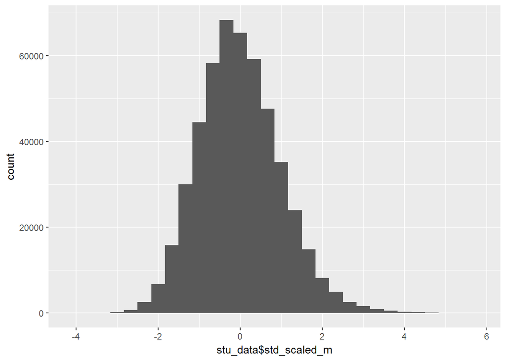

```r
library(ggplot2)

qplot(stu_data$std_scaled_m)
```

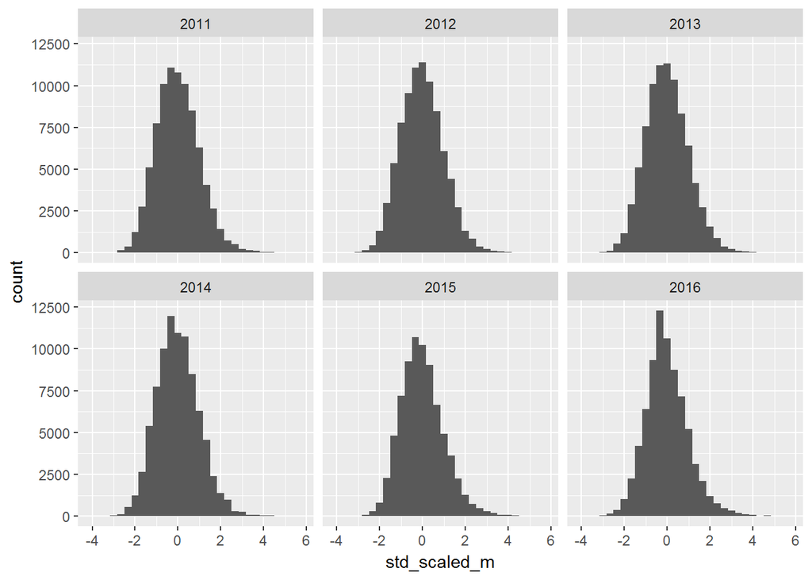

```r
qplot(data = stu_data, std_scaled_m) + facet_wrap(~school_year)
```

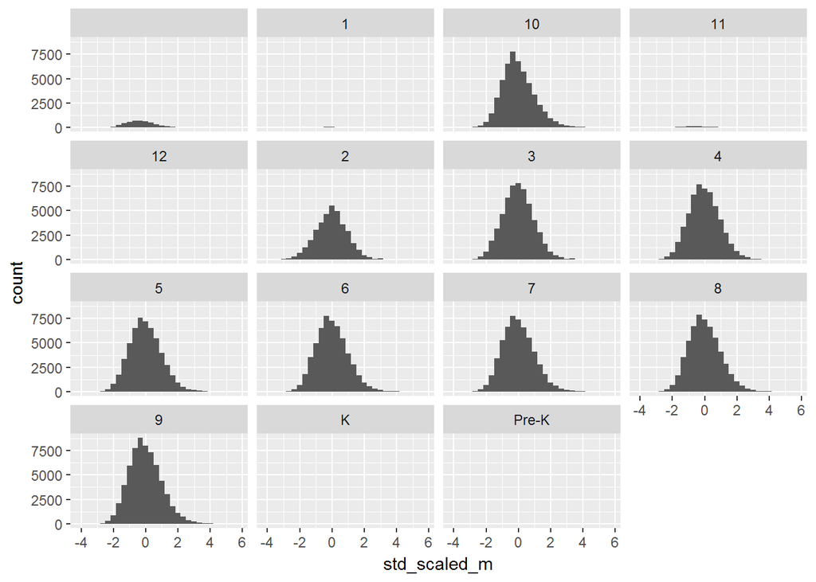

```r
qplot(data = stu_data, std_scaled_m) + facet_wrap(~s_grade_level)
```

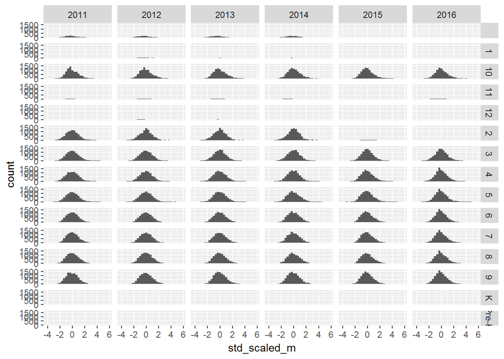

```r
qplot(data = stu_data, std_scaled_m) + facet_grid(s_grade_level~school_year)
```

**Question 16: When did the state stop administering math tests to second graders?**

R graphing commands have a plethora of options, and `qplot` is not an exception. Tolearn the syntax and the options for any command, you can go to the help page for that command by typing `?` in front of the function name like below:

```r
?qplot
```

Review the overall distributions for the ELA scores. In this case we’ll skip the grade-by-year plot since the data has already been reviewed above.

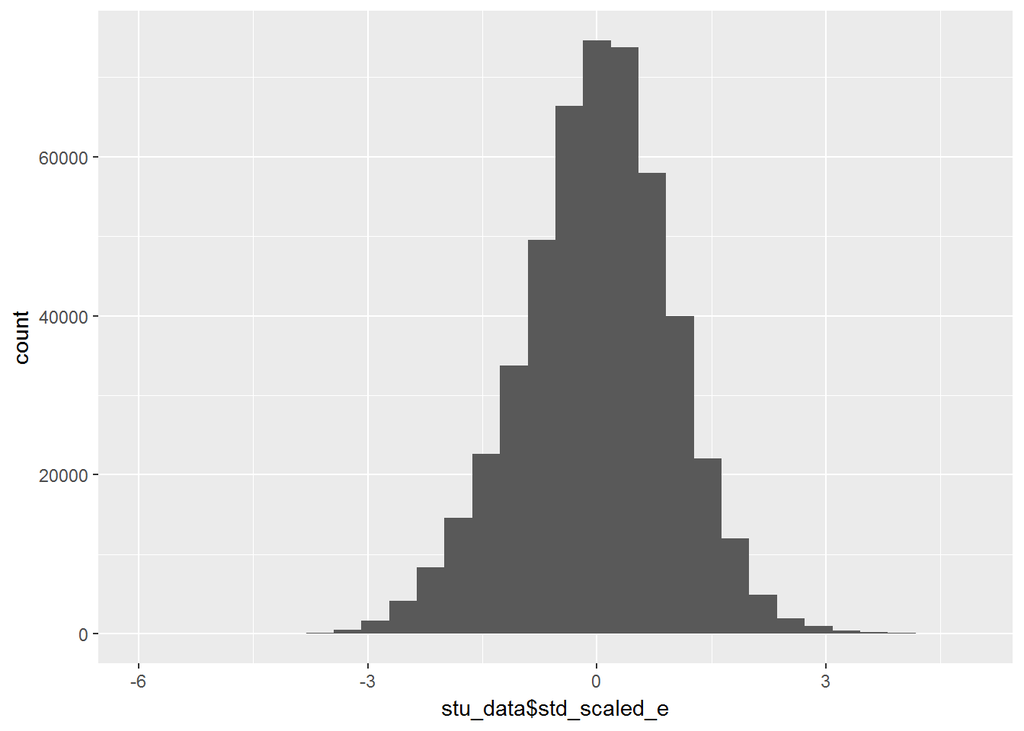

```r
qplot(stu_data$std_scaled_e)
```

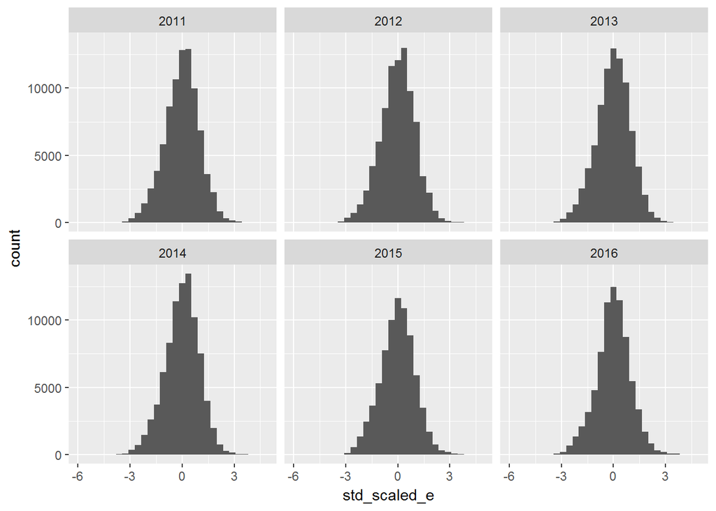

```r
qplot(data = stu_data, std_scaled_e) + facet_wrap(~school_year)
```

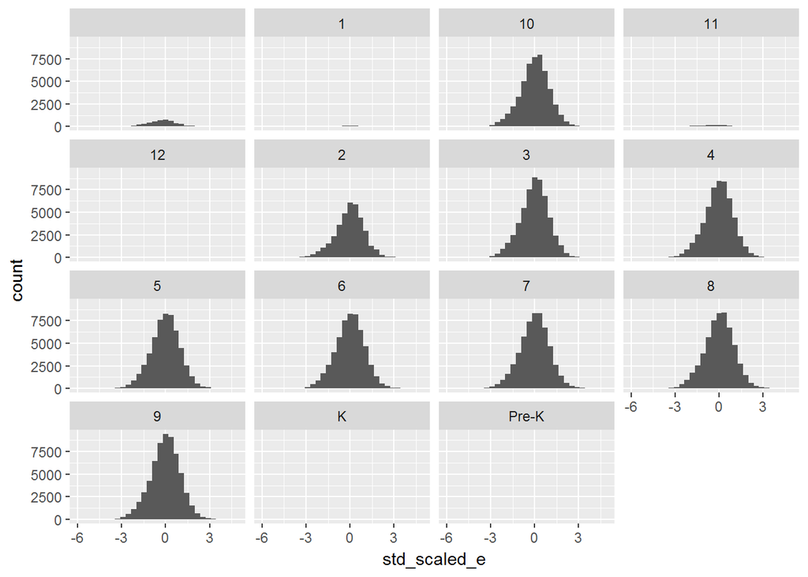

```r
qplot(data = stu_data, std_scaled_e) + facet_wrap(~s_grade_level)
```

Before looking at the histogram of SAT scores, check the coverage across years. One way to do this is to use the `by()` function with the `summary()` command. The first argument to `by()` is the variable we want to apply a function to, the second argument is the group we want to split the variable by, and the third argument is the function we want to apply - `FUN = summary`.

```r
# By year
by(stu_data$sat_math_score, stu_data$school_year, FUN = summary)
```

```
stu_data$school_year: 2011
   Min. 1st Qu.  Median    Mean 3rd Qu.    Max.    NA's
  200.0   400.0   460.0   469.3   540.0   800.0   96879
------------------------------------------------------------
stu_data$school_year: 2012
   Min. 1st Qu.  Median    Mean 3rd Qu.    Max.    NA's
  200.0   390.0   460.0   466.7   540.0   800.0  102075
------------------------------------------------------------
stu_data$school_year: 2013
   Min. 1st Qu.  Median    Mean 3rd Qu.    Max.    NA's
  200.0   390.0   460.0   463.3   530.0   800.0  107117
------------------------------------------------------------
stu_data$school_year: 2014
   Min. 1st Qu.  Median    Mean 3rd Qu.    Max.    NA's
  200.0   390.0   460.0   458.7   530.0   800.0  113285
------------------------------------------------------------
stu_data$school_year: 2015
   Min. 1st Qu.  Median    Mean 3rd Qu.    Max.    NA's
  200.0   380.0   450.0   452.2   520.0   800.0  115313
------------------------------------------------------------
stu_data$school_year: 2016
   Min. 1st Qu.  Median    Mean 3rd Qu.    Max.    NA's
  200.0   370.0   440.0   445.9   520.0   800.0  119889
```

```r
# By grade
by(stu_data$sat_math_score, stu_data$s_grade_level, FUN = summary)
```

```
stu_data$s_grade_level:
   Min. 1st Qu.  Median    Mean 3rd Qu.    Max.    NA's
    200     380     450     451     520     780   16122
------------------------------------------------------------
stu_data$s_grade_level: 1
   Min. 1st Qu.  Median    Mean 3rd Qu.    Max.    NA's
  380.0   420.0   460.0   466.7   510.0   560.0   59838
------------------------------------------------------------
stu_data$s_grade_level: 10
   Min. 1st Qu.  Median    Mean 3rd Qu.    Max.    NA's
  200.0   390.0   460.0   462.8   530.0   800.0   38429
------------------------------------------------------------
stu_data$s_grade_level: 11
   Min. 1st Qu.  Median    Mean 3rd Qu.    Max.    NA's
  200.0   390.0   460.0   465.7   540.0   800.0   26210
------------------------------------------------------------
stu_data$s_grade_level: 12
   Min. 1st Qu.  Median    Mean 3rd Qu.    Max.    NA's
    200     400     460     469     540     800   19981
------------------------------------------------------------
stu_data$s_grade_level: 2
   Min. 1st Qu.  Median    Mean 3rd Qu.    Max.    NA's
  460.0   467.5   515.0   512.5   560.0   560.0   57183
------------------------------------------------------------
stu_data$s_grade_level: 3
   Min. 1st Qu.  Median    Mean 3rd Qu.    Max.    NA's
  460.0   467.5   510.0   510.0   552.5   560.0   57373
------------------------------------------------------------
stu_data$s_grade_level: 4
   Min. 1st Qu.  Median    Mean 3rd Qu.    Max.    NA's
  350.0   430.0   465.0   468.3   530.0   560.0   56691
------------------------------------------------------------
stu_data$s_grade_level: 5
   Min. 1st Qu.  Median    Mean 3rd Qu.    Max.    NA's
    220     355     410     402     460     550   56411
------------------------------------------------------------
stu_data$s_grade_level: 6
   Min. 1st Qu.  Median    Mean 3rd Qu.    Max.    NA's
    200     340     410     415     490     710   57027
------------------------------------------------------------
stu_data$s_grade_level: 7
   Min. 1st Qu.  Median    Mean 3rd Qu.    Max.    NA's
    200     370     440     445     520     800   51795
------------------------------------------------------------
stu_data$s_grade_level: 8
   Min. 1st Qu.  Median    Mean 3rd Qu.    Max.    NA's
  200.0   380.0   450.0   454.3   530.0   800.0   47850
------------------------------------------------------------
stu_data$s_grade_level: 9
   Min. 1st Qu.  Median    Mean 3rd Qu.    Max.    NA's
    200     390     460     459     530     800   51241
------------------------------------------------------------
stu_data$s_grade_level: K
   Min. 1st Qu.  Median    Mean 3rd Qu.    Max.    NA's
     NA      NA      NA     NaN      NA      NA   53820
------------------------------------------------------------
stu_data$s_grade_level: Pre-K
   Min. 1st Qu.  Median    Mean 3rd Qu.    Max.    NA's
     NA      NA      NA     NaN      NA      NA    4587
```

You can use the by prefix with many R functions. The fact that the number of observations decreases in the most recent years, and that there are values for many grade levels, makes it seem likely that the data is not structured so that SAT scores appear only in the testing year. Browse the data to verify this.

```r
stu_data %>% arrange(sid, school_year) %>%
  select(sid, school_year, s_grade_level, starts_with("sat")) %>%
  View()
```

It appears that for any students who took the SAT anywhere in 2011-2016, the score appears in all years the student is in the data. Examine the SAT score prevalence just for 12th graders across time. Note that you must apply the grade-level restriction to both arguments to the `by()` function.

```r
by(stu_data$sat_math_score[stu_data$s_grade_level == 12],
   stu_data$school_year[stu_data$s_grade_level == 12], summary)
```

```
stu_data$school_year[stu_data$s_grade_level == 12]: 2011
   Min. 1st Qu.  Median    Mean 3rd Qu.    Max.    NA's
  200.0   410.0   480.0   483.4   550.0   800.0    3118
------------------------------------------------------------
stu_data$school_year[stu_data$s_grade_level == 12]: 2012
   Min. 1st Qu.  Median    Mean 3rd Qu.    Max.    NA's
  200.0   410.0   470.0   478.6   550.0   800.0    3477
------------------------------------------------------------
stu_data$school_year[stu_data$s_grade_level == 12]: 2013
   Min. 1st Qu.  Median    Mean 3rd Qu.    Max.    NA's
  200.0   400.0   470.0   479.1   550.0   800.0    4037
------------------------------------------------------------
stu_data$school_year[stu_data$s_grade_level == 12]: 2014
   Min. 1st Qu.  Median    Mean 3rd Qu.    Max.    NA's
  200.0   410.0   480.0   478.6   540.0   800.0    3873
------------------------------------------------------------
stu_data$school_year[stu_data$s_grade_level == 12]: 2015
   Min. 1st Qu.  Median    Mean 3rd Qu.    Max.    NA's
  200.0   400.0   460.0   466.6   540.0   800.0    3838
------------------------------------------------------------
stu_data$school_year[stu_data$s_grade_level == 12]: 2016
   Min. 1st Qu.  Median    Mean 3rd Qu.    Max.    NA's
  200.0   370.0   440.0   446.2   520.0   800.0    1638
```

**Question 17: What pattern do you see?**

For completeness, check the distribution by year for 12th graders. Here we introduce an alternative way to specify plots in R. It takes a little getting used to, but it will enable you to quickly and easily make production quality graphics with just a few commands. Here we specify the dataset we are using in the `ggplot()` command, and we use `aes()` to specify which variables in that dataset we want to use and where on the plot to assign them, in this case to the X-axis. We then add a histogram to this function using `geom_histogram()`. Use the `binwidth` option to make the bars line up with actual SAT scores. Finally, as before, we “facet” the graph by school year using `facet_wrap()`.

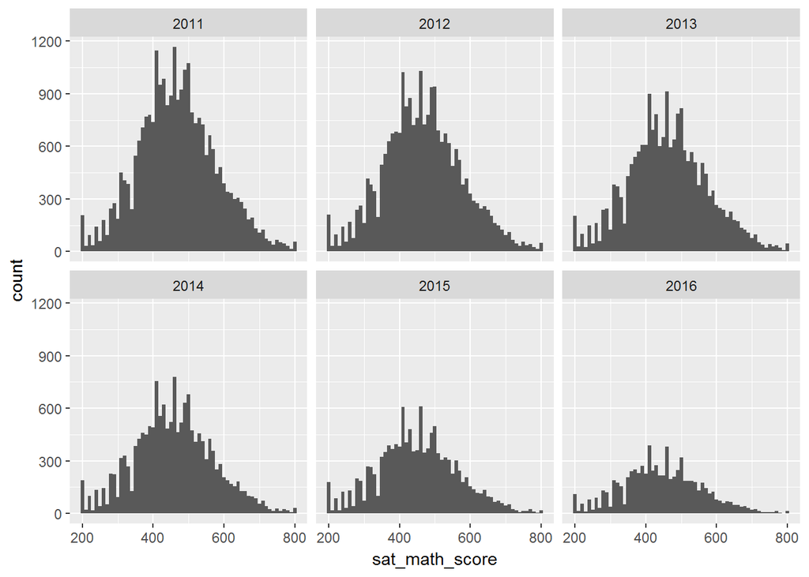

```r
ggplot(stu_data, aes(x = sat_math_score)) + geom_histogram(binwidth = 10) +
  facet_wrap(~school_year)
```

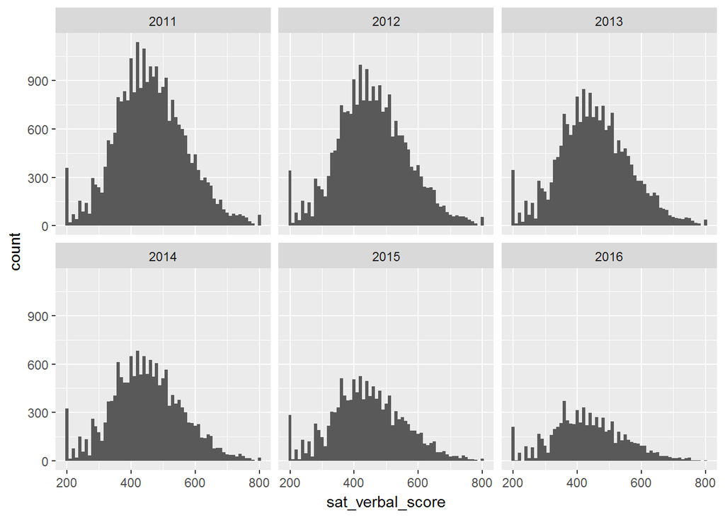

```r
ggplot(stu_data, aes(sat_verbal_score)) + geom_histogram(binwidth = 10) +
  facet_wrap(~school_year)
```

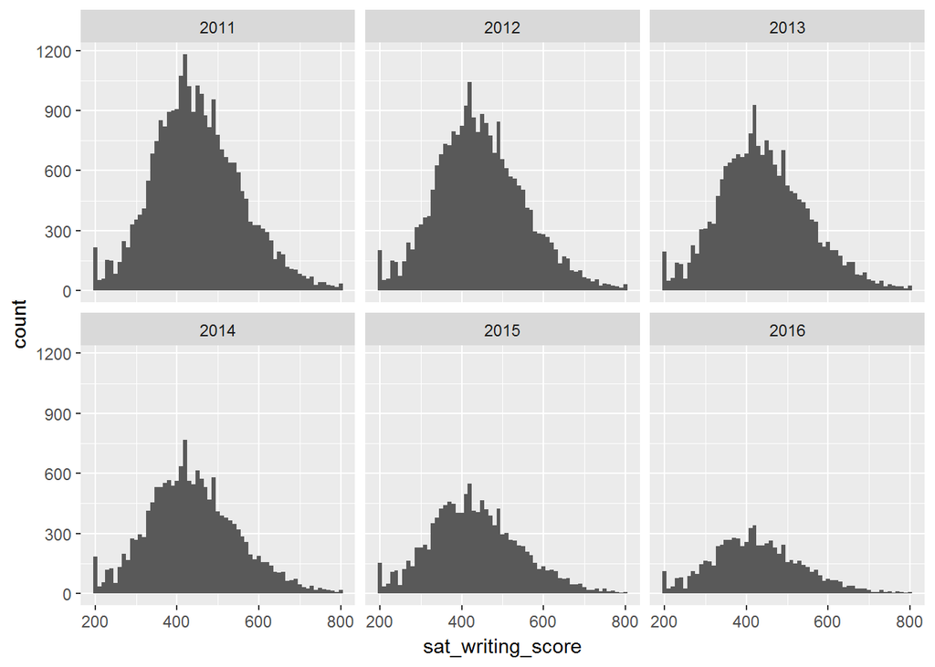

```r
ggplot(stu_data, aes(sat_writing_score)) + geom_histogram(binwidth = 10) +
  facet_wrap(~school_year)
```

If you want to compare the distributions of two continuous variables, you can make a scatter plot, or use the correlation command.

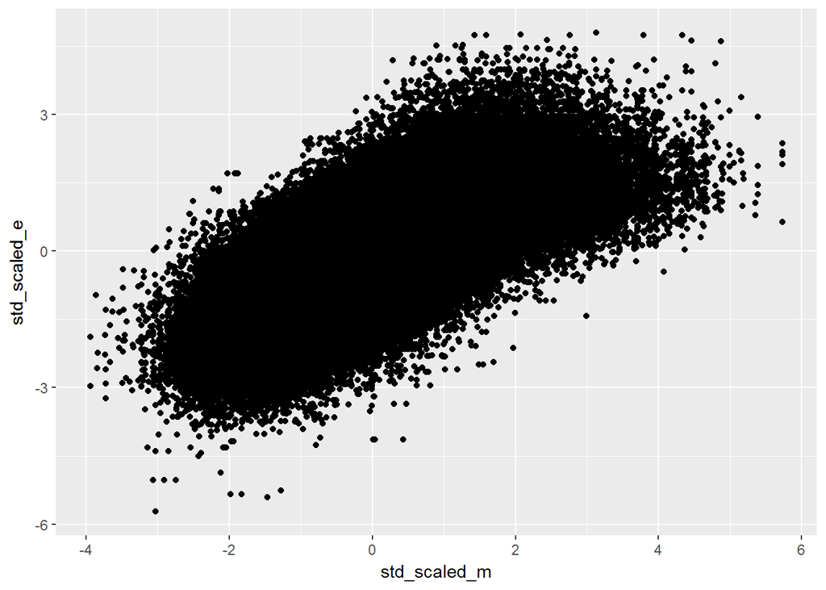

```r
qplot(x = std_scaled_m, y = std_scaled_e, data = stu_data)
```

By default if `NA` values are present, the correlation will be `NA` as well, we have to tell R which observations to use – in most cases you will select “pairwise.complete.obs”, which matches the default of most other software packages like Stata or SPSS.

```r
cor(stu_data$std_scaled_m, stu_data$std_scaled_e,
    use = "pairwise.complete.obs")
```

```
[1] 0.7176879
```

Correlation measures the strength of the linear relationship between two variables, and it varies from -1 to 1. Two variables with zero correlation have no relationship, while variables that are identical have a correlation of 1. Variables that are negatively correlated (as one tends to increase, the other tends to decrease) have a correlation less than zero.

```r
cor(stu_data$std_scaled_m, stu_data$std_scaled_m, use = "pairwise.complete.obs")
```

```
[1] 1
```

```r
cor(stu_data$s_days_absent, stu_data$std_scaled_e, use = "pairwise.complete.obs")
```

```
[1] -0.1244642
```

You can also make a correlation table of multiple variables, including dummy variables. Check to see that the signs and strengths of the correlations are what you expect.

```r
stu_data %>% select(starts_with("std"), starts_with("sat"),
                    s_ell, s_iep, hs_diploma) %>%
  cor(use = "pairwise")
```

```
                  std_scaled_m std_scaled_e sat_math_score sat_verbal_score
std_scaled_m        1.00000000   0.71768785     0.76534203       0.63683449
std_scaled_e        0.71768785   1.00000000     0.61464922       0.68709345
sat_math_score      0.76534203   0.61464922     1.00000000       0.54736797
sat_verbal_score    0.63683449   0.68709345     0.54736797       1.00000000
sat_writing_score   0.64970825   0.63219581     0.74190191       0.53638389
s_ell              -0.10621883  -0.13018875    -0.10061053      -0.11777200
s_iep              -0.31949991  -0.32587473    -0.23613944      -0.22068751
hs_diploma          0.05744809   0.05602003     0.09958692       0.08629715
                  sat_writing_score       s_ell       s_iep  hs_diploma
std_scaled_m             0.64970825 -0.10621883 -0.31949991  0.05744809
std_scaled_e             0.63219581 -0.13018875 -0.32587473  0.05602003
sat_math_score           0.74190191 -0.10061053 -0.23613944  0.09958692
sat_verbal_score         0.53638389 -0.11777200 -0.22068751  0.08629715
sat_writing_score        1.00000000 -0.09850927 -0.22606830  0.09575019
s_ell                   -0.09850927  1.00000000 -0.01367984 -0.07121145
s_iep                   -0.22606830 -0.01367984  1.00000000 -0.05481549
hs_diploma               0.09575019 -0.07121145 -0.05481549  1.00000000
```

For comparing the distributions of categorical and continuous variables, there are several options. One of the most compact is to use the table command. Without options, the table command works much like the tab command.

```r
table(stu_data$school_year, sch_vocation = stu_data$sch_vocational)
```

```
      sch_vocation
            0      1
  2011 117110   5960
  2012 119007   6061
  2013 121522   5356
  2014 122875   6564
  2015 120571   7107
  2016 120211   7176
```

```r
stu_data %>% group_by(s_frpl) %>% filter(s_grade_level == 8) %>%
  summarize(mean_math = mean(std_scaled_m, na.rm=TRUE),
            mean_eng = mean(std_scaled_e, na.rm=TRUE))
```

| s_frpl | mean_math | mean_eng |
| --- | --- | --- |
| Does Not Qualify | 0.2656526 | 0.2353770 |
| Free Lunch | -0.3238404 | -0.2992453 |
| Reduced Lunch | -0.1705803 | -0.1466889 |

**Question 18: what is the average math score for students receiving free in lunch in 8th grade?**

Note that these test scores have been standardized to have an average of 0 and a standard deviation of 1.

You can also examine categorical and continuous variables together using box plots. To do this, we add an `x` and a `y` argument to the `aes()` function. For variables coded 0 and 1, it is necessary to tell R that you want these treated as categories, or “factors” in R lingo, which the `factor()` function does.

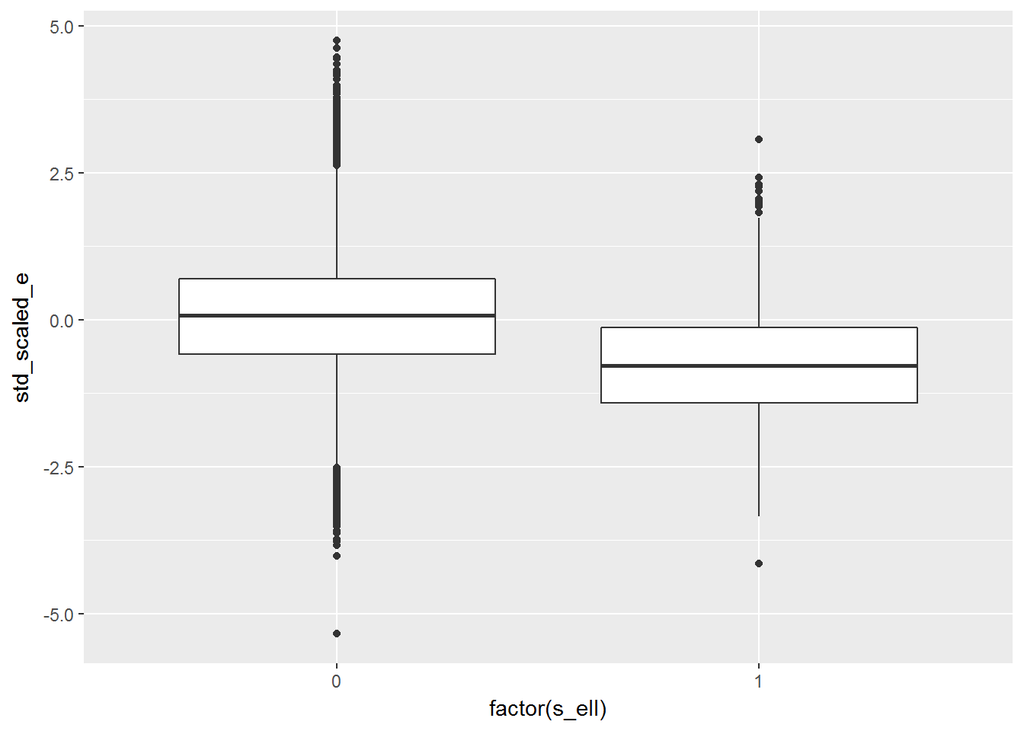

```r
ggplot(stu_data[stu_data$s_grade_level == 8, ],
       aes(y = std_scaled_e, x = factor(s_ell))) + geom_boxplot()
```

Here you can see that English language learners have a lower median 8th grade ELA score than other students.

Before finishing this part of the tutorial and moving on to asking questions using the data, there are two more syntactical issues in R you should be aware of. First, it’s possible to make complicated sample restrictions using the if statement with AND `&` and OR `|` logical operators. The vertical pipe symbol (|) that R uses for OR is located above the backslash on the keyboard. You can use parentheses to make the precedence of the operators clear if necessary.

While `table()` is useful for looking at a quick comparison, when you want to apply complex filters or summarize over a variable with many categories, in R it is useful to group the data and summarize. Using the `%>%` we’ve already seen above, this is very simple.

```r
stu_data %>% group_by(s_male) %>%
  filter(s_grade_level == 7 & (school_year == 2015 | school_year == 2016)) %>%
  summarize(median_absences = median(s_days_absent, na.rm=TRUE))
```

| s_male | median_absences |
| --- | --- |
| 0 | 6 |
| 1 | 7 |

You can also use `!=` as a comparison operator that means “not equals.”

```r
stu_data %>% group_by(s_male, s_grade_level) %>%
  filter(school_year != 2011 & school_year != 2012) %>%
  summarize(median_absences = median(s_days_absent))
```

| s_male | s_grade_level | median_absences |
| --- | --- | --- |
| 0 |  | NA |
| 0 | 1 | NA |
| 0 | 10 | NA |
| 0 | 11 | NA |
| 0 | 12 | NA |
| 0 | 2 | NA |
| 0 | 3 | NA |
| 0 | 4 | NA |
| 0 | 5 | NA |
| 0 | 6 | NA |

[output cut: 20 more lines]

**Question 19: Explain what this table shows.**

The second thing to note is a quirk of the numeric missing symbol. In comparison expressions, R treats missing as matching any possible value. This means you sometimes need to explicitly exclude missing values when you use comparison operators. Suppose you want to know the number of students with greater than or equal to 9 absences in 2016.

```r
nrow(stu_data[stu_data$s_days_absent >= 9 & stu_data$school_year == 2016,])
```

```
[1] 48497
```

```r
nrow(stu_data[stu_data$s_days_absent >= 9 & !is.na(stu_data$s_days_absent) &
                stu_data$school_year == 2016,])
```

```
[1] 47320
```

Because R treats `NA` as any possible number, the first command counts students with missing absence totals, and the second command does not.

# PART 2: USING THE DATA TO ASK QUESTIONS

Now that you’ve finished the “getting to know the data” phase, you can start to ask interesting questions! For this part of the tutorial, you’ll enter most commands directly into the R window.

In this part you won’t be trying to check on characteristics of variables in the dataset; you want to ask questions about specific groups of students. Here are some steps to think through when you are writing exploratory Stata commands to do descriptive analysis:

What is the specific research question that I am interested in? This determines the choice of variables. You can use your knowledge from the data inspection phase to map research questions to variables.

How should I restrict my data to be sure that I’m using the right observations? This determines the filters you apply to your data in R.

How should I show the results? This determines the Stata command and options you choose. Sometimes it can take some experimenting to get your output to look exactly the way you want it to.

We’ll start by asking questions about achievement gaps in math for different student subgroups. Then, we’ll inquire into high school graduation outcomes by subgroup. These questions can be answered using the table and tab commands. Finally, we’ll try to determine which factors are associated with graduating on-time in four years, using linear and logistic regression commands.

A note about regression: if you have taken at least a one-semester class in statistics and econometrics, you are probably already familiar with some of the theory behind linear and logistic regression. Regression analysis is important in education research for describing data, developing predictive models, and evaluating the impact of programs. If you haven’t learned these methods in an academic setting, though, you may not feel comfortable applying them in your own work, and teaching you everything you need to know about regression is outside the scope of this tutorial. However, this tutorial does end with a demonstration of regression commands to provide some exposure to how they work and how to interpret regression output.

In case you’re just coming back to the tutorial, you can start by reloading the data.

```r
# Clear workspace
rm(list = ls())
library(dplyr) # loads a library of useful functions for data manipulation
# If dplyr is not installed use
# install.packages("dplyr")
# Use read.csv to import CSV style data
stu_data <- read.csv("data/Delawnymous_SSY_20170813.csv",
                     stringsAsFactors = FALSE)
```

Let’s begin by restricting the sample to our student group of interest. Think carefully about which years of data you should use to explore high school graduation. By eleventh or twelfth grade, many students who won’t go on to graduate will have leftschool already. Typically graduation rates are calculated for cohorts of ninth-graders. The latest year in the data is 2016, and graduates in that year would have been ninth-graders in 2013. Graduates in 2015 would have been ninth graders in 2012. We can calculate four-year graduation rates for students in 2013, and five-year graduation rates for students in 2012. However, we are missing absence data for 2012. Let’s use ninth graders in 2013 to examine both achievement disparities by race and disparities in graduation rates. (For this exercise, we will ignore students who transfer in or out of the state after ninth grade.)

```r
stu_data_g9 <- stu_data[stu_data$s_grade_level == 9 &
                          stu_data$school_year == 2013,]
summary(stu_data_g9$std_scaled_m, na.rm=TRUE)
```

```
   Min. 1st Qu.  Median    Mean 3rd Qu.    Max.    NA's
-3.0230 -0.7029 -0.0716  0.0153  0.6582  4.8330     658
```

Note that the average score is very close to zero, and the standard deviation is very close to 1. This is a typical way of standardizing assessment scores to aide in statistical modeling and interpretation.

Next, let’s begin by looking descriptively at achievement disparities. A good practice is to look at means and variances of achievement scores by key demographic indicators to get a sense of scale and proportion for disparities and inform furthe ranalysis. First, how different are math scores by gender? You can use the `by()` function to answer this.

```r
by(stu_data_g9$std_scaled_m, stu_data_g9$s_male, mean, na.rm=TRUE)
```

```
stu_data_g9$s_male: 0
[1] 0.003707321
------------------------------------------------------------
stu_data_g9$s_male: 1
[1] 0.02645535
```

```r
# Alternatively
by(stu_data_g9$std_scaled_m, stu_data_g9$s_male, summary)
```

```
stu_data_g9$s_male: 0
    Min.  1st Qu.   Median     Mean  3rd Qu.     Max.     NA's
-2.83000 -0.69690 -0.07499  0.00371  0.63260  4.83300      301
------------------------------------------------------------
stu_data_g9$s_male: 1
   Min. 1st Qu.  Median    Mean 3rd Qu.    Max.    NA's
-3.0230 -0.7029 -0.0363  0.0265  0.6811  4.8330     357
```

Next, how do math scores vary for these students by race/ethnicity? R hint: In the command window, you can save typing by using the page up key to bring up previous commands and edit them.

```r
by(stu_data_g9$std_scaled_m, stu_data_g9$s_race, summary)
```

```
stu_data_g9$s_race: Asian
    Min.  1st Qu.   Median     Mean  3rd Qu.     Max.     NA's
-2.69000 -0.08313  0.60000  0.70290  1.42400  4.62700       22
------------------------------------------------------------
stu_data_g9$s_race: Black
   Min. 1st Qu.  Median    Mean 3rd Qu.    Max.    NA's
-2.8300 -0.9896 -0.4790 -0.4092  0.1203  3.9400     271
------------------------------------------------------------
stu_data_g9$s_race: Hispanic
   Min. 1st Qu.  Median    Mean 3rd Qu.    Max.    NA's
-2.5900 -0.8631 -0.2635 -0.1911  0.4494  2.8630      66
------------------------------------------------------------
stu_data_g9$s_race: Multiple
   Min. 1st Qu.  Median    Mean 3rd Qu.    Max.    NA's
-1.8220 -0.5172  0.2909  0.2319  0.8509  2.9020       2
------------------------------------------------------------
stu_data_g9$s_race: Native American
   Min. 1st Qu.  Median    Mean 3rd Qu.    Max.    NA's
-1.4070 -0.5073  0.0854  0.1260  0.8542  1.7680       6
------------------------------------------------------------
stu_data_g9$s_race: Other
    Min.  1st Qu.   Median     Mean  3rd Qu.     Max.
-1.43300 -0.39250 -0.10750 -0.19390 -0.02474  0.96880
------------------------------------------------------------
stu_data_g9$s_race: White
   Min. 1st Qu.  Median    Mean 3rd Qu.    Max.    NA's
-3.0230 -0.4100  0.2290  0.2780  0.9135  4.8330     291
```

*How do math scores vary by free lunch status?*

```r
by(stu_data_g9$std_scaled_m, stu_data_g9$s_frpl, summary)
```

```
stu_data_g9$s_frpl: Does Not Qualify
   Min. 1st Qu.  Median    Mean 3rd Qu.    Max.    NA's
-2.8300 -0.4606  0.1941  0.2573  0.9135  4.8330     297
------------------------------------------------------------
stu_data_g9$s_frpl: Free Lunch
   Min. 1st Qu.  Median    Mean 3rd Qu.    Max.    NA's
-3.0230 -0.9716 -0.4313 -0.3697  0.1535  4.6270     312
------------------------------------------------------------
stu_data_g9$s_frpl: Reduced Lunch
   Min. 1st Qu.  Median    Mean 3rd Qu.    Max.    NA's
-2.6900 -0.8503 -0.3094 -0.2197  0.3325  3.7740      49
```

Another good step is to also investigate how key student characteristics vary by each other, as we saw in Part One: How does free lunch status vary by race for these students? Use the tab command.

*How does free lunch status vary by race for these students? Use the tab command.*

```r
round(prop.table(table(stu_data_g9$s_frpl, stu_data_g9$s_race), margin = 1), 3)
```

```
                   Asian Black Hispanic Multiple Native American Other White
  Does Not Qualify 0.039 0.221    0.048    0.005           0.003 0.000 0.683
  Free Lunch       0.018 0.527    0.152    0.005           0.007 0.001 0.292
  Reduced Lunch    0.018 0.487    0.103    0.000           0.007 0.001 0.384
```

*How do ninth grade math scores vary by English Language Learner status?*

```r
by(stu_data_g9$std_scaled_m, stu_data_g9$s_ell, summary)
```

```
stu_data_g9$s_ell: 0
   Min. 1st Qu.  Median    Mean 3rd Qu.    Max.    NA's
-3.0230 -0.6936 -0.0328  0.0325  0.6712  4.8330     629
------------------------------------------------------------
stu_data_g9$s_ell: 1
    Min.  1st Qu.   Median     Mean  3rd Qu.     Max.     NA's
-2.69000 -1.26000 -0.70290 -0.63250 -0.08313  2.35200       29
```

*How do ninth grade math scores vary by special education status?*

```r
by(stu_data_g9$std_scaled_m, stu_data_g9$s_iep, summary)
```

```
stu_data_g9$s_iep: 0
   Min. 1st Qu.  Median    Mean 3rd Qu.    Max.    NA's
-2.7300 -0.5332  0.0641  0.1528  0.7679  4.8330     408
------------------------------------------------------------
stu_data_g9$s_iep: 1
   Min. 1st Qu.  Median    Mean 3rd Qu.    Max.    NA's
-3.0230 -1.3910 -0.9200 -0.8429 -0.3663  3.1330     250
```

We should also look at disparities by school-level factors. Use the table command to look at math scores by school type:

*What are average ninth grade math scores for charter school students?*

```r
by(stu_data_g9$std_scaled_m, stu_data_g9$sch_charter, summary)
```

```
stu_data_g9$sch_charter: 0
   Min. 1st Qu.  Median    Mean 3rd Qu.    Max.    NA's
-3.0230 -0.7263 -0.0766 -0.0155  0.6173  4.8330     619
------------------------------------------------------------
stu_data_g9$sch_charter: 1
   Min. 1st Qu.  Median    Mean 3rd Qu.    Max.    NA's
-2.3270 -0.3705  0.4581  0.5218  1.2810  4.8330      39
```

*Vocational students?*

```r
by(stu_data_g9$std_scaled_m, stu_data_g9$sch_vocational, summary)
```

```
stu_data_g9$sch_vocational: 0
   Min. 1st Qu.  Median    Mean 3rd Qu.    Max.    NA's
-3.0230 -0.7414 -0.0831 -0.0161  0.6138  4.8330     628
------------------------------------------------------------
stu_data_g9$sch_vocational: 1
   Min. 1st Qu.  Median    Mean 3rd Qu.    Max.    NA's
-2.5450 -0.4121  0.2642  0.2728  0.9478  3.9540      30
```

*Alternative school students?*

```r
by(stu_data_g9$std_scaled_m, stu_data_g9$sch_alternative, summary)
```

```
stu_data_g9$sch_alternative: 0
   Min. 1st Qu.  Median    Mean 3rd Qu.    Max.    NA's
-3.0230 -0.7029 -0.0716  0.0168  0.6582  4.8330     620
------------------------------------------------------------
stu_data_g9$sch_alternative: 1
    Min.  1st Qu.   Median     Mean  3rd Qu.     Max.     NA's
-2.53100 -0.66470 -0.07294 -0.02759  0.58120  3.13300       38
```

How do ninth grade math scores vary by attendance? Let’s make a scatterplot.

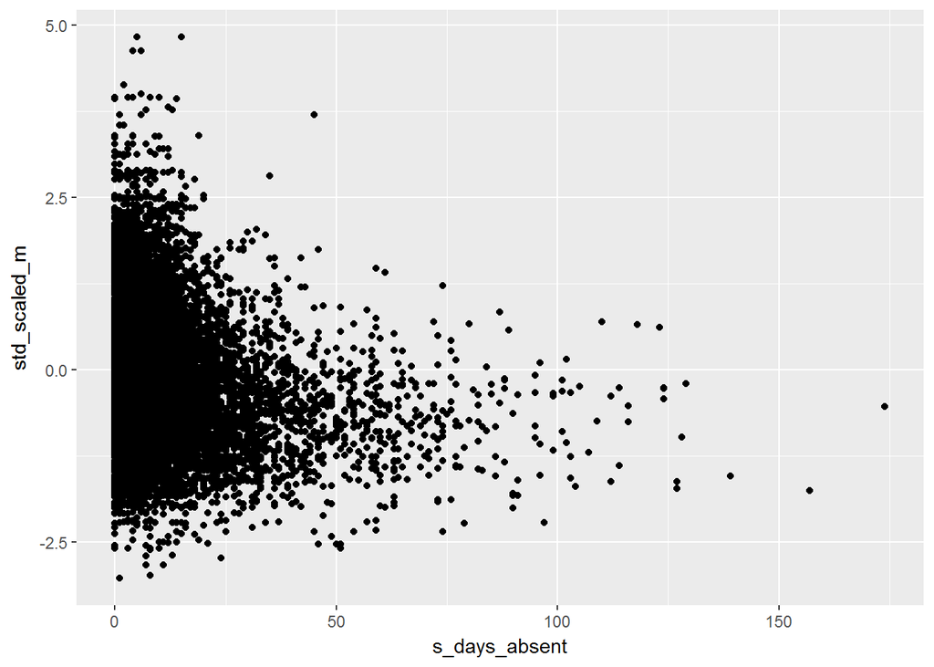

```r
library(ggplot2)
ggplot(stu_data_g9, aes(x = s_days_absent, y = std_scaled_m)) + geom_point()
```

*As is typical with student-level education data, there are so many data points that they cover each other up, but it does look as if test scores tend to be lower for students with more absences, as expected. You can add a fitted line to see the relationship more clearly.*

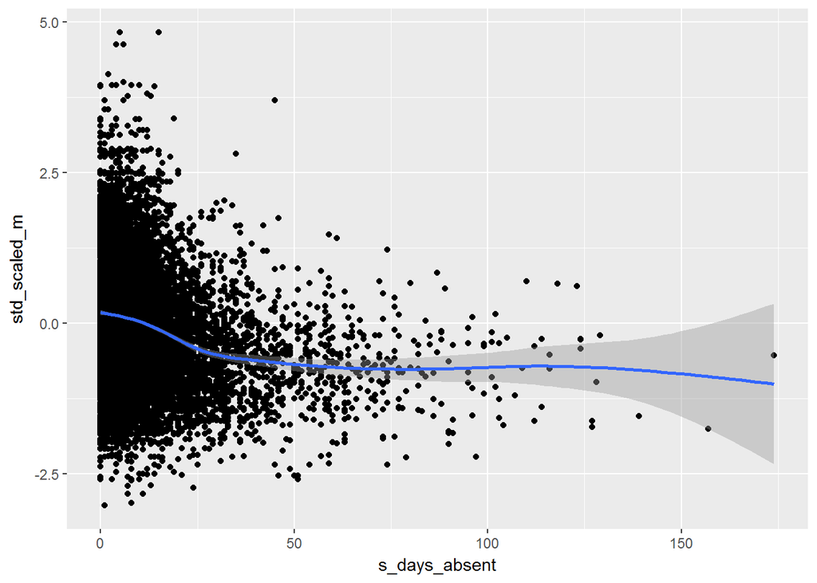

```r
ggplot(stu_data_g9, aes(x = s_days_absent, y = std_scaled_m)) + geom_point() +
  geom_smooth()
```

Adding a fitted line is as easy as adding another “layer” to the plot using the `geom_smooth()` command. By default, this function will fit a loess smoother, but if you want to see a trend line, you can use `geom_smooth(method = 'lm')` and fit a linear model instead.

Next, let’s turn our attention to high school graduation as an outcome. We have seen the magnitude of disparities that exist by student and school factors in math scores, so it is logical to look at the relationship between math scores and high school graduation.

*What is the average ninth grade math score for graduates and non-graduates? Use the by function*

```r
# Look at table using by command
by(stu_data$std_scaled_m, stu_data$hs_diploma, mean, na.rm=TRUE)
```

```
stu_data$hs_diploma: 0
[1] -0.03307643
------------------------------------------------------------
stu_data$hs_diploma: 1
[1] 0.1254978
```

The disparity in math scores between graduates and non-graduates suggests the two variables are strongly related. At this point, you should look at the relationship between graduation and student and school characteristics following the same process as we did above for math scores.

Another way to approach this is to construct a correlation table to look at these relationship simultaneously. A correlation table is another way to quantify the strength of the linear relationship between high school graduation and other numeric variables (including dummy variables). The correlation table will show the the correlations for every pair of variables you give it, which allows you to compare correlations with your outcome, but also among key factors such as race/ethnicity and days suspended or absent.

You should exclude `s_frpl` and `s_race`, since these are categorical variables with more than two categories. (Note that it’s possible to redefine these variables as a series of dummy variables–for example, to define a separate 0/1 variable for each race/ethnicity category–but we haven’t done that.) You should also exclude SAT scores, since there are large numbers of missing values in 2013, and because the SAT is usually taken in 11th or 12th grades. The `cor` command will drop observations with any missing values.

```r
stu_data_g9 %>%
  select(hs_diploma, s_male, s_ell, s_iep, starts_with("s_days_"),
         starts_with("std_scaled_"),
         starts_with("sch_"),
         s_birth_year) %>%
  cor(use = "pairwise") %>% round(digits = 2)
```

```
                 hs_diploma s_male s_ell s_iep s_days_absent s_days_suspended
hs_diploma             1.00  -0.05 -0.04 -0.14         -0.33            -0.16
s_male                -0.05   1.00 -0.01  0.09          0.02             0.06
s_ell                 -0.04  -0.01  1.00  0.01          0.03             0.02
s_iep                 -0.14   0.09  0.01  1.00          0.13             0.10
s_days_absent         -0.33   0.02  0.03  0.13          1.00             0.29
s_days_suspended      -0.16   0.06  0.02  0.10          0.29             1.00
std_scaled_m           0.23   0.01 -0.10 -0.34         -0.23            -0.18
std_scaled_e           0.22  -0.10 -0.11 -0.35         -0.19            -0.19
sch_charter            0.02   0.01 -0.02 -0.05          0.00            -0.01
sch_alternative        0.01  -0.03  0.01  0.00         -0.02            -0.03
sch_vocational         0.15  -0.02 -0.03 -0.05         -0.09            -0.04
s_birth_year           0.26  -0.07 -0.06 -0.14         -0.27            -0.10
                 std_scaled_m std_scaled_e sch_charter sch_alternative
hs_diploma               0.23         0.22        0.02            0.01
s_male                   0.01        -0.10        0.01           -0.03
s_ell                   -0.10        -0.11       -0.02            0.01
s_iep                   -0.34        -0.35       -0.05            0.00
s_days_absent           -0.23        -0.19        0.00           -0.02
s_days_suspended        -0.18        -0.19       -0.01           -0.03
std_scaled_m             1.00         0.74        0.12           -0.01
std_scaled_e             0.74         1.00        0.09            0.00
sch_charter              0.12         0.09        1.00           -0.05
sch_alternative         -0.01         0.00       -0.05            1.00
sch_vocational           0.09         0.08       -0.08           -0.06
s_birth_year             0.19         0.17        0.01           -0.03
                 sch_vocational s_birth_year
hs_diploma                 0.15         0.26
s_male                    -0.02        -0.07
s_ell                     -0.03        -0.06
s_iep                     -0.05        -0.14
s_days_absent             -0.09        -0.27
s_days_suspended          -0.04        -0.10
std_scaled_m               0.09         0.19
std_scaled_e               0.08         0.17
sch_charter               -0.08         0.01
sch_alternative           -0.06        -0.03
sch_vocational             1.00         0.09
s_birth_year               0.09         1.00
```

Looking just at the first `hs_diploma` column, you can see that high school graduation is most strongly correlated (or negatively correlated) with ninth grade absences, not being an older student, test scores, suspensions, and attending a vocational school. Based on the crosstabs, we know that free lunch status and race/ethnicity are also strongly related to graduation outcomes.

However, many of these variables are correlated with one another–they vary together. Given that students with higher absences also tend to have lower test scores, what is the difference in the probability of graduation associated with having higher test scores for students with the same number of absences? What is the difference in the probability of graduation associated with more days of absence for students who have the same test scores? We can use regression commands to tease out and quantify these differences.

With our data, we can’t develop a model that shows that higher absences or lower test scores in ninth grade cause non-graduation, because higher absences and lower test scores could be related to another unobserved factor that is actually causing students to drop out. But, we can use a regression model to better understand the associations in the data and estimate the probability of dropping out.

To get a feel for how regression works, let’s look at a simple example with `hs_diploma` as the outcome (dependent) variable, and `s_male` as a single predictor (independent) variable. Here is the R syntax for a linear regression:

```r
simple_model <- lm(hs_diploma ~ s_male, data = stu_data_g9)
summary(simple_model)
```

```
Call:
lm(formula = hs_diploma ~ s_male, data = stu_data_g9)

Residuals:
    Min      1Q  Median      3Q     Max
-0.7008 -0.6498  0.2992  0.3503  0.3503

Coefficients:
             Estimate Std. Error t value Pr(>|t|)
(Intercept)  0.700852   0.006232 112.466  < 2e-16 ***
s_male      -0.051097   0.008709  -5.867 4.56e-09 ***
---
Signif. codes:  0 '***' 0.001 '**' 0.01 '*' 0.05 '.' 0.1 ' ' 1

Residual standard error: 0.4678 on 11547 degrees of freedom
Multiple R-squared:  0.002972,  Adjusted R-squared:  0.002886
F-statistic: 34.42 on 1 and 11547 DF,  p-value: 4.558e-09
```

*Look particularly at three numbers in the regression output.*

The coefficient (the number under Estimate next to `s_male`) estimates the linear relationship between being male (the independent variable) and graduating from high school (the dependent variable).

The `t-value` (under Pr>|t|) (roughly the same as a p-value) is a measure of the statistical significance of the relationship. It gives the probability of seeing the coefficient by chance if there were actually no relationship between `s_male` and `hs_diploma`. The R-squared value gives the share of the variation in `hs_diploma` that is explained by the independent variables (in this case, just `s_male`) in the regression.

The coefficient is actually the slope of a fitted line for a graph with the independent variable on the x axis and the dependent variable on the y axis. (The (Intercept) value is the intercept of the line.) Remembering that the slope of a line is rise over run, you can interpret the coefficient of a univariate linear regression in this way: “Every one-unit change in the independent variable is associated with an estimated change in the dependent variable equal to the coefficient.”

This makes more sense when the y variable is a continuous variable rather than a dummy variable, but it is still a valid interpretation for this model. Since `s_male` is a dummy variable, a one unit increase from 0 to 1 is the same as the difference between being not male and male. `hs_diploma` can only take on the values of 0 or 1, but we can interpret the coefficient as an estimated change in the probability of graduation. Thus another way to state the interpretation is that being male is associated with a 5.1 percent decrease in the probability of graduation. In fact, if you look at the results of the crosstab above, you will see that this is exactly the difference in graduation rates for male and female students in our sample.

Because the p-value is very small (less than or equal to 0.000), the relationship between gender and high school graduation is highly statistically significant.

On the other hand, according to the R-squared value, gender alone explains only three-tenths of a percent of the total variation in high school graduation. Clearly other factors are also at work.

*Compare this with the output from a tab command:*

```r
prop.table(table(male = stu_data_g9$s_male,
                 diploma =stu_data_g9$hs_diploma), margin = 2)
```

```
    diploma
male         0         1
   0 0.4487623 0.5069302
   1 0.5512377 0.4930698
```

To better understand what factors influence graduation, let’s look at a multivariate regression which includes multiple student characteristics that we think are strongly related to related to high school graduation, based on our data exploration and our knowledge of education. Note the use of the `factor()` function for `s_frpl` and `s_race`. It instructs R to convert those categorical variables into a series of dummy variables for use in the regression.

```r
multi_model <- lm(hs_diploma ~ s_days_absent + s_days_suspended +
                    factor(s_frpl) + factor(s_iep) + factor(s_race) +
                    std_scaled_m + std_scaled_e + s_birth_year +
                    s_male + sch_vocational, data = stu_data_g9)
summary(multi_model)
```

```
Call:
lm(formula = hs_diploma ~ s_days_absent + s_days_suspended +
    factor(s_frpl) + factor(s_iep) + factor(s_race) + std_scaled_m +
    std_scaled_e + s_birth_year + s_male + sch_vocational, data = stu_data_g9)

Residuals:
    Min      1Q  Median      3Q     Max
-1.3786 -0.4101  0.1716  0.2912  1.5204

Coefficients:
                                Estimate Std. Error t value Pr(>|t|)
(Intercept)                   -1.441e+02  1.038e+01 -13.887  < 2e-16 ***
s_days_absent                 -6.809e-03  3.147e-04 -21.641  < 2e-16 ***
s_days_suspended              -3.459e-03  8.576e-04  -4.034 5.53e-05 ***
factor(s_frpl)Free Lunch      -6.144e-02  1.002e-02  -6.131 9.04e-10 ***
factor(s_frpl)Reduced Lunch   -3.143e-03  1.634e-02  -0.192 0.847437
factor(s_iep)1                -2.984e-02  1.281e-02  -2.329 0.019878 *
factor(s_race)Black            2.848e-02  2.655e-02   1.072 0.283552
factor(s_race)Hispanic         3.643e-02  2.910e-02   1.252 0.210733
factor(s_race)Multiple        -1.520e-02  6.525e-02  -0.233 0.815764
factor(s_race)Native American  9.743e-02  6.711e-02   1.452 0.146583
factor(s_race)Other           -1.168e-01  1.738e-01  -0.672 0.501620
factor(s_race)White            4.413e-02  2.579e-02   1.711 0.087110 .
std_scaled_m                   3.615e-02  6.372e-03   5.672 1.45e-08 ***
std_scaled_e                   2.110e-02  6.224e-03   3.390 0.000703 ***
s_birth_year                   7.254e-02  5.196e-03  13.962  < 2e-16 ***
s_male                        -2.277e-02  8.339e-03  -2.731 0.006325 **
sch_vocational                 1.524e-01  1.319e-02  11.556  < 2e-16 ***
---
Signif. codes:  0 '***' 0.001 '**' 0.01 '*' 0.05 '.' 0.1 ' ' 1

Residual standard error: 0.4212 on 10574 degrees of freedom
  (958 observations deleted due to missingness)
Multiple R-squared:  0.1635,    Adjusted R-squared:  0.1622
F-statistic: 129.1 on 16 and 10574 DF,  p-value: < 2.2e-16
```

You can see a number of interesting things about this regression. For example, with the other control variables included, race is not a significant predictor of graduation in our data. The p-values are larger than .05, a typical threshold for statistical significance.

All of the other variables are statistically significant, except for being eligible for reduced price lunch.

R automatically omitted dummy variables for Asian and for no FRL. These are the base cases that the other dummy variables in those categories measure change against. So, for example, being eligible for free lunch is associated with an estimated 6.1 percent decrease in the probability of graduation compared with not being ligible for a free lunch.

Because this is a multivariate model, you need to assume that all other variables are held constant when you are interpreting the coefficient. For example, a one-standard-deviation increase in ninth grade math score is associated with an estimated 3.6 percent increase in graduation probability, holding all other variables constant.

After you have run a regression, you can have R calculate the fitted results for each data point and store them in a new variable using the `<-` operator. Let’s call this `yhat`.

```r
# Assign fitted values to the original data
stu_data_g9$yhat <- predict(multi_model, newdata = stu_data_g9)
```

You can look at the distribution of the fitted probabilities from the regression model and compare them to actual graduation outcomes.

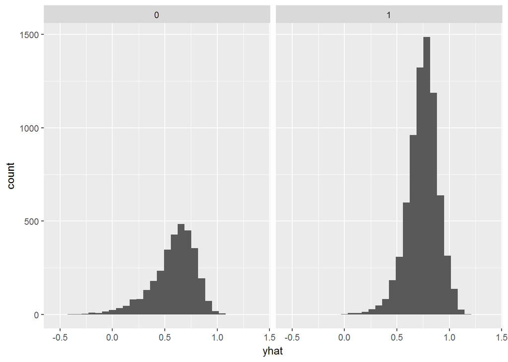

```r
ggplot(stu_data_g9, aes(x = yhat)) + geom_histogram() + facet_wrap(~hs_diploma)
```

If we use a .5 cutoff for the fitted probabilities to predict graduation, it looks as if the linear model did a good job of predicting graduates, but also had a number of “false positives” among non-graduates.

Because linear models can predict probabilities greater than one or less than zero, when the dependent variable is a dummy variable, as in this case, analysts often prefer to use a generalized linear model which constrains the fitted values to fit a specific distribution. Logistic regression is the most common example, which restricts the fitted values to being between 0 and 1, and is suitable for analyzing outcome data where there are only two possible outcomes. Here is a generalized linear model (GLM) “logistic” regression using the logit command. Note it is very similar to the `lm()` command above, with an additional argument `family = "binomial"` to tell it to fit a binomial model.

```r
multi_logit <- glm(hs_diploma ~ s_days_absent + s_days_suspended +
                    factor(s_frpl) + factor(s_iep) + factor(s_race) +
                    std_scaled_m + std_scaled_e + s_birth_year +
                    s_male + sch_vocational, data = stu_data_g9,
                   family = binomial)
summary(multi_logit)
```

```
Call:
glm(formula = hs_diploma ~ s_days_absent + s_days_suspended +
    factor(s_frpl) + factor(s_iep) + factor(s_race) + std_scaled_m +
    std_scaled_e + s_birth_year + s_male + sch_vocational, family = binomial,
    data = stu_data_g9)

Deviance Residuals:
    Min       1Q   Median       3Q      Max
-2.9474  -0.9430   0.5925   0.7983   3.3061

Coefficients:
                                Estimate Std. Error z value Pr(>|z|)
(Intercept)                   -7.336e+02  5.697e+01 -12.877  < 2e-16 ***
s_days_absent                 -3.590e-02  1.999e-03 -17.964  < 2e-16 ***
s_days_suspended              -1.411e-02  4.633e-03  -3.046  0.00232 **
factor(s_frpl)Free Lunch      -3.142e-01  5.392e-02  -5.828 5.62e-09 ***
factor(s_frpl)Reduced Lunch   -4.010e-02  9.070e-02  -0.442  0.65839
factor(s_iep)1                -1.197e-01  6.778e-02  -1.767  0.07730 .
factor(s_race)Black            1.709e-01  1.520e-01   1.124  0.26099
factor(s_race)Hispanic         2.010e-01  1.653e-01   1.216  0.22411
factor(s_race)Multiple        -1.016e-01  3.614e-01  -0.281  0.77858
factor(s_race)Native American  5.535e-01  3.989e-01   1.388  0.16528
factor(s_race)Other           -5.491e-01  8.958e-01  -0.613  0.53988
factor(s_race)White            2.451e-01  1.488e-01   1.647  0.09950 .
std_scaled_m                   2.209e-01  3.728e-02   5.927 3.08e-09 ***
std_scaled_e                   1.099e-01  3.510e-02   3.130  0.00175 **
s_birth_year                   3.679e-01  2.852e-02  12.900  < 2e-16 ***
s_male                        -1.305e-01  4.715e-02  -2.767  0.00565 **
sch_vocational                 1.177e+00  1.033e-01  11.397  < 2e-16 ***
---
Signif. codes:  0 '***' 0.001 '**' 0.01 '*' 0.05 '.' 0.1 ' ' 1

(Dispersion parameter for binomial family taken to be 1)

    Null deviance: 13017  on 10590  degrees of freedom
Residual deviance: 11211  on 10574  degrees of freedom
  (958 observations deleted due to missingness)
AIC: 11245

Number of Fisher Scoring iterations: 4
```

Unlike a linear model, the coefficients in the output for a logistic regression can’t be interpreted in a straightforward way. However, you can review the statistical significance of each variable.

You can also use the predict command to generate fitted values and make predictions.

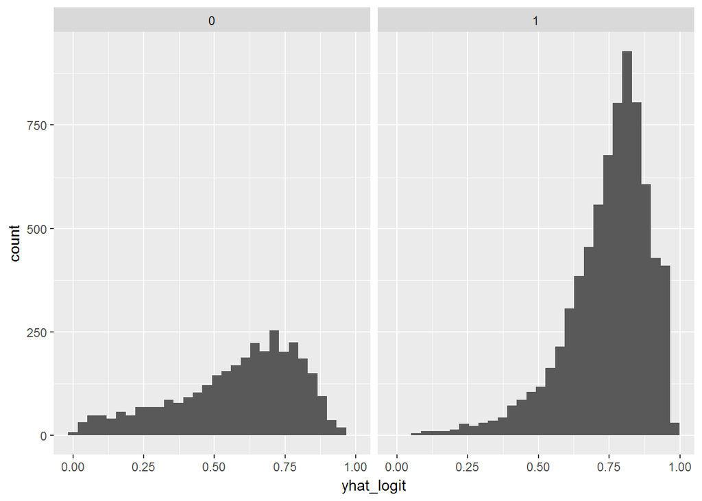

```r
stu_data_g9$yhat_logit <- predict(multi_logit, newdata = stu_data_g9,
                                  type = "response")
ggplot(stu_data_g9, aes(x = yhat_logit)) + geom_histogram() +
  facet_wrap(~hs_diploma)
```

Congratulations! You’ve gone from exploring a new data set to performing multivariate regression in only a few short steps. The commands and the analysis steps you learned here will be helpful to prepare you for diving deeper into using regression for inference and prediction in your future work.